# Caracterización de los efectos de la Fluoxetina sobre el aprendizaje espacial y la flexibilidad cognitiva en un modelo de estrés crónico en ratón

Autor/a

Afiliación

Garcia Rios Santiago

[Facultad de Ciencias](https://www.fciencias.unam.mx/)

Fecha de publicación

29 de abril de 2024

Resumen

El estrés crónico tiene efectos profundos sobre distintos aspectos de la cognición, incluyendo la flexibilidad cognitiva dependiente del hipocampo (Tafet y Nemeroff, 2016). Estos impactos cognitivos pueden ser estudiados en modelos de roedores utilizando el Laberinto Acuático de Morris (MWM) (Hernández-Mercado y Zepeda, 2022). Sin embargo, estos estudios han dependido predominantemente del análisis de métricas y métodos estadísticos que no necesariamente modelan la relación entre el estrés crónico y la flexibilidad cognitiva dependiente del hipocampo. Aunque estos métodos han aportado valiosas perspectivas, sus limitaciones para manejar conjuntos de datos biológicos complejos son cada vez más reconocidos. Esta problemática se observa en la creciente literatura que no ha logrado encontrar una relación clara entre el estrés crónico, mecanismos cognitivos afectados a nivel de hipocampo y el efecto antidepresivo de fármacos como fluoxetina (David et al., 2009). Este estudio explora las ventajas de utilizar técnicas de análisis que modelen mejor la relación para el estudio de la flexibilidad cognitiva. A través de un análisis comparativo que involucra a ratones sometidos a estrés crónico y tratamiento farmacológico con fluoxetina, demostramos cómo estos enfoques pueden proporcionar interpretaciones más matizadas de los datos, acomodando la variabilidad individual y la estructura jerárquica de los diseños experimentales comúnmente utilizados en esta área. Nuestros hallazgos revelan que estos enfoques no solo ofrecen una mayor flexibilidad y precisión predictiva, sino que también mejoran la comprensión de los efectos cognitivos del estrés y la eficacia de posibles intervenciones. Al integrar metodologías estadísticas avanzadas con protocolos experimentales rigurosos, esta investigación contribuye al perfeccionamiento de los modelos de neurociencia cognitiva y apoya el desarrollo de estrategias terapéuticas dirigidas para las alteraciones cognitivas relacionadas con el estrés.

Palabras clave

Morris Water Maze, Cognitive Flexibility, Mixed Models.

# 1 Introducción

## 1.1 Estrés, desórdenes de ánimo y flexibilidad Cognitiva

### 1.1.1 Depresión

Caracterizada por sentimientos persistentes de tristeza, pérdida de interés o placer, y una variedad de síntomas físicos y cognitivos, el trastorno depresivo mayor tiene un impacto profundo en la calidad de vida de un individuo. De acuerdo con la Organización Panamericana de la Salud (OPS), la proporción de la población mundial con depresión en 2015 fue de 4.4% (3.6% en hombres y 5.1% en mujeres). Además, se estima que para 2020, la depresión sea la segunda causa a nivel mundial de discapacidad y que un 20% de la población mundial sufra de algún trastorno afectivo que requiera tratamiento médico en algún momento de su vida (**cerecero-garcía2020?**) . Este panorama resalta la necesidad urgente de comprender mejor los mecanismos subyacentes de la depresión y desarrollar tratamientos más efectivos y accesibles.

trastorno depresivo mayor – estado de ánimo bajo, anhedonia, cambios en peso, sueño, fatiga, sentimientos de culpa, concentración baja

TA generalizada – preocupaciones excesivas, persistentes e incontrolables, dificultad para concentrarse

El impacto de la depresión es significativo y multifacético. Aquí están algunas de las formas en que la depresión puede afectar a las personas y a la sociedad:

#### 1.1.1.1 Depresión y cognición

Los trastornos depresivos van más allá de los síntomas emocionales, afectando profundamente las capacidades cognitivas de los individuos. Estos problemas cognitivos, que incluyen dificultades en la atención, memoria y la flexibilidad cognitiva, son a menudo algunos de los aspectos más debilitantes de la depresión. La hace referencia a la capacidad de una persona para adaptarse y cambiar su pensamiento en respuesta a situaciones cambiantes o nuevas. Esta habilidad implica poder cambiar de perspectiva o enfoque mental y adaptarse a nuevas reglas o expectativas. La flexibilidad cognitiva es una parte importante de la función ejecutiva, un conjunto de habilidades cognitivas que nos permiten planificar, organizar, tomar decisiones, mantener la atención, y regular el comportamiento (Anacker y Hen 2017). Esta capacidad de adaptar el pensamiento y el comportamiento a situaciones nuevas y cambiantes, es crucial para manejar las complejidades de la vida diaria.

En personas con depresión, la disminución de la flexibilidad cognitiva puede manifestarse en una dificultad para desvincularse de pensamientos negativos y adaptarse a nuevos contextos o perspectivas, lo que a su vez puede perpetuar y agravar los síntomas depresivos. De manera similar, en los desórdenes de ansiedad también se puede observar una falta de flexibilidad cognitiva como pensamientos negativos recurrentes que agravian el padecimiento (**uddin2021?**).

La mayoría de los pacientes con trastornos depresivos experimentan, en cierta medida, deterioros cognitivos. Parece que los trastornos cognitivos constituyen un síntoma patológico central de la depresión y no deberían ser considerados simplemente como secundarios a ella. Por lo tanto, los síntomas cognitivos deben ser vistos como una dimensión parcialmente independiente del trastorno depresivo mayor y un objetivo importante de cualquier tratamiento que se implemente (Maramis, Mahajudin, y Khotib 2021).

La flexibilidad conductual es la manifestación física de la flexibilidad cognitiva. Como veremos más adelante, la flexibilidad conductual puede ser evaluada mediante el aprendizaje reversa. Esta tarea es vulnerables al estrés. El estrés crónico e impredecible perjudica tanto el aprendizaje de reversión (Hurtubise y Howland 2017).

### 1.1.2 Estrés

Estímulo no placentero, aversivo y/o amenazante para la homeostasis de un individuo (Lucassen et al. 2016).

Richard Lazarus define al estrés cen torno a una relación entre el individuo y el ambiente, el cual es experimentado de manera significativa o demandande que exede los recursos para lidiar con él (ver coping theory, Lazarus & Folkman, 1984).

- (M. N. Hill et al. 2012)
- (**petkovic2022?**)

Estresores crónicos, impredecibles e incontrolables son causa mayor de desordenes depresivos y de ansiedad (**hill2012a?**).

Diversos factores afectan la respuesta al estrés y la susceptibilidad de que desencadene trastornos, como depresivos o de ansiedad. Estos van desde aspectos psicológicos (experiencia subjetiva del estrés, recursos para lidiar con estresores), hasta biológicos (cascadas neuroendócrinas, procesamiento de información) (Tafet y Nemeroff 2016).

Si nos mantenemos estresados, nuestra respuesta fisiológica no será suficiente.

#### 1.1.2.2 Regulación del eje hipotálamo-hipofisario-suprarrenal

La activación del eje hipotálamo-hipofisario-suprarrenal () tiene consecuencias importantes sobre los receptores de glucocorticoides () del .

La activación crónica del eje puede generar problemas en la fisiología del organismo, incluyendo bucles de que resulten en la activación persistente del sistema (Tafet y Nemeroff 2016).

#### 1.1.2.3 Papel de Neurotransmisores

**Serotonina**

La serotonina () se une a receptores pre y post sinápticos (se han identificado hasta 14 tipos en 7 familias). Se cree que la administración crónica de antidepresivos ( ) (y el subsecuente aumento de en el espacio sináptico) desensibiliza o regula a la baja los somatodentríticos de tipo $5-HT_{1A}$ en el , a la vez que regula a la alta $5-HT_{1A}$ post-sinápticos y desensibiliza $5-HT_{2A}$ (Tafet y Nemeroff 2016).

**Dopamina**

La dopamina está relacionada con la regulación del eje , así como en la fisiopatología de la depresión. Los principales grupos de neuronas dopaminérgicas en el SNC incluyen el campo retro-rubro (A8), la sustancia negra pars compacta (A9) y el área tegmental ventral (A10), de donde emergen las vías mesolímbica y mesocortical. La vía mesolímbica se proyecta principalmente hacia el núcleo accumbens y otras estructuras límbicas, incluyendo la amígdala, el hipocampo, el núcleo de la estría terminal y el septum, y está implicada en el procesamiento y refuerzo de estímulos gratificantes, motivación y la experiencia subjetiva del placer. La vía mesocortical se proyecta principalmente hacia la corteza prefrontal (PFC), el cíngulo anterior (ACC) y la corteza entorrinal, y juega un papel crucial en funciones cognitivas como la concentración y la memoria de trabajo. Además, los estrsores ambientales incrementan la actividad del la amígdala, incrementando la concentración de dopamina en la vía mesocortical (particularmente en PFC), confiriendo un aumento de la saliencia relacinada a estímulos negativos (Tafet y Nemeroff 2016).

**Norepinefrina**

El principal grupo de neuronas que contienen norepinefrina en el SNC se localiza en el locus coeruleus (LC), desde donde surgen diversas proyecciones que inervan ampliamente áreas corticales y subcorticales, incluyendo la amígdala, el hipocampo y el núcleo paraventricular del hipotálamo. Estas proyecciones al área tegmental ventral han demostrado potenciar la liberación de dopamina, mientras que las proyecciones al núcleo del rafe regulan la liberación de serotonina (5-HT). También se ha observado una regulación recíproca entre la norepinefrina y la 5-HT, no solo a través de conexiones entre ambos sistemas aminérgicos, sino también mediante estructuras límbicas como el hipocampo. Además, las conexiones recíprocas entre la norepinefrina y las neuronas que contienen factor de liberación de corticotropina (CRF) sugieren un papel crucial del LC en la regulación de las respuestas neurales y neuroendocrinas al estrés. En respuesta a estresores agudos, se libera norepinefrina en diferentes estructuras del SNC, resultando en un aumento de la alerta y la hipervigilancia, en el contexto de respuestas adaptativas al estrés. La activación del LC también ha sido asociada con la estimulación del hipotálamo lateral, que participa en la activación de la rama simpática del sistema nervioso autónomo, complementando así la respuesta adaptativa al estrés (Tafet y Nemeroff 2016).

#### 1.1.2.4 Inflamación

Las concentraciones elevadas de citoquinas proinflamatorias producidas por el estrés agudo (interleucina-1, la interleucina-6 y el factor de necrosis tumoral-alfa), se han vinculado a los efectos de diversos estímulos ambientales y esta activación inmunitaria también se ha observado en la depresión mayor. Además, se ha encontrado que la depresión mayor puede inducir respuestas inflamatorias incrementadas al estrés. Los estresores ambientales activan la rama simpática del sistema nervioso autónomo, resultando en la liberación de catecolaminas que, a su vez, activan sus receptores en las células inmunes y estimulan la liberación de citoquinas proinflamatorias. Las respuestas inflamatorias crónicas en el SNC pueden resultar en la liberación excesiva de citoquinas proinflamatorias, lo que puede llevar a concentraciones reducidas de neurotrofinas (incluido el BDNF), provocando neuroplasticidad deteriorada y disminución de la neurogénesis (especialmente en el hipocampo), asociadas con el origen de trastornos cognitivos y del estado de ánimo. Las citoquinas proinflamatorias también están involucradas en la regulación del eje HPA, estimulando la liberación de CRF y resultando en hipercortisolismo, lo que ha sido asociado con una sensibilidad reducida de los GR y resistencia a los glucocorticoides. Niveles elevados de cortisol, como los observados durante el estrés crónico, pueden llevar a una síntesis disminuida de 5-HT debido a la actividad reducida de la enzima limitante de la velocidad, la triptófano hidroxilasa.

#### 1.1.2.5 Neuroplasticidad

Muchos factores neurotróficos (especialmente neurotrofinas) se han asociado a la respuesta del estrés crónico, incluyendo el factor de crecimiento nervioso, el factor neurotrófico derivado del cerebro (BDNF), neurotrofina-3, neurotrofina-4/5 y neurotrofina-6. Entre estas, el BDNF ha recibido particular atención debido a su papel en la regulación del desarrollo cerebral, la neuroplasticidad y la neurogénesis. Los estudios sugieren que niveles reducidos de BDNF pueden conducir a síntomas depresivos, mientras que su regulación positiva está asociada con la recuperación clínica. Estudios in vitro han mostrado que el BDNF puede disminuir la captación de serotonina (5-HT), indicando su posible papel en la regulación del transportador de serotonina (5-HTT). El estrés crónico y la activación resultante del eje hipotalámico-pituitario-adrenal (HPA) pueden dañar neuronas en ciertas estructuras del SNC, especialmente en el hipocampo, donde se han encontrado altos niveles de receptores de glucocorticoides (GRs) (Tafet y Nemeroff 2016).

La neurogénesis en el sistema nervioso central (SNC) adulto puede ser estimulada por condiciones específicas, especialmente aquellas relacionadas con una actividad hipocampal aumentada y niveles elevados de serotonina (5-HT), pero puede ser inhibida por situaciones estresantes y niveles altos de glucocorticoides. Bajo condiciones de estrés crónico y con la activación incrementada del eje hipotalámico-pituitario-adrenal (HPA), la inhibición de la neurogénesis hipocampal puede interferir con la formación de nuevas cogniciones, contribuyendo así a provocar y mantener condiciones que inducen depresión. Según esta hipótesis, las intervenciones terapéuticas exitosas podrían requerir la recuperación de la tasa normal de neurogénesis hipocampal. Esta recuperación podría estar asociada con un efecto directo de los antidepresivos al incrementar los niveles de 5-HT o indirectamente a través de la modulación del eje HPA y el aumento de los niveles de BDNF, lo cual se ha asociado con una regulación positiva de la neuroplasticidad y el aumento de la neurogénesis. Sin embargo, esta hipótesis sigue siendo controvertida debido a la falta de confirmación del aumento en la neurogénesis tras tratamientos antidepresivos a largo plazo (Tafet y Nemeroff 2016). Por ejemplo, reducir la neurogénesis por otros factores que no involucren estrés no causa fenotipos de tipo depresivos.

De acuerdo a (**vollmayr2003?**), la tasa de proliferación celular en el giro dentado se regula a la baja de manera aguda por el estrés, pero el desarrollo de comportamiento de desesperanza aprendida no correlaciona con este proceso.

El estrés crónico se ha asociado a cambios en el volumen de varias regiones cerebrales, incluido el hipocampo. En la literatura, se han reportado variaciones en el volumen del hipocampo en la depresión, que pueden estar relacionadas con diferencias en la duración de la enfermedad, la delimitación anatómica, la lateralización, las condiciones de vida temprana y el genotipo. En general, los cambios en el hipocampo, la amígdala y la corteza prefrontal en el trastorno depresivo mayor (MDD) son hallazgos bien replicados en la psiquiatría. No está claro si la pérdida de volumen del hipocampo refleja una causa o una consecuencia del MDD, pero se puede prever que volúmenes más bajos del hipocampo en los pacientes están asociados con una mayor duración y recurrencia de episodios depresivos, el tamaño de sus respuestas integradas de cortisol, y una historia de estrés temprano en la vida. Además, un volumen más pequeño del hipocampo podría predisponer al desarrollo de psicopatologías (Lucassen et al. 2016).

De acuerdo con investigaciones lideradas por Igor Branchini (**branchi2023?**) y (**dellicolli2024?**), los niveles altos de plasticidad inducidos por medicamentos, como los antidepresivos serotoninérgicos y los psicodélicos, no son beneficiosos por sí mismos. Estos fármacos inducen una alta plasticidad (a veces llamados psicoplastógenos) que hacen que el cerebro y el comportamiento sean más susceptibles a cambios según factores contextuales, como las condiciones de vida. Esta suceptibilidad puede ser benéfica si las condiciones de vida mejoran. Sin embargo, si las condiciones de vida no mejoran (o empeoran), esta plasticidad inducida por los fármacos puede ser detrimental.

#### 1.1.2.6 Paul Willner y el Modelo de Estrés Crónico

Estresores crónicos, impredecibles e incontrolables son causa mayor de desordenes depresivos y de ansiedad (**hill2012a?**).

Estos investigadores observaron que la exposición prolongada a una serie de estresores leves pero impredecibles, los animales desarrollarían un estado de disminución en la saliencia de la recompensa similar a la anhedonia observada en el trastorno depresivo mayor (**hill2012a?**).

Con base en esto, este modelo ha sigo utilizado para examinan variables neurobiológicas asociadas con la depresión, aunque no se ha examinado críticamente para validar que los cambios neurobiológicos inducidos por CMS sean paralelos a los documentados en el trastorno depresivo. (1) provoca una serie de cambios neurobiológicos que reflejan aquellos vistos en los trastornos depresivos y (2) puede ser una herramienta adecuada para investigar nuevos sistemas que podrían estar alterados en la depresión, y así ayudar en el desarrollo de nuevos objetivos para el tratamiento de la depresión (**hill2012a?**).

Validez de predicción (rendimiento en prueba predice el rendimiento que queremos modelar; en este caso se ve con fármacos). Validez de apariencia (similitudes fenomenológicas – comparación con DSM-V); validez de constructo (modelo tiene bases teóricas razonables – mecanismos neurobiológicos) (Willner, 2017)

Entre los sistemas que afecta (ver revisión de (**hill2012a?**)), están:

Sistema serotoninérgico: ere are almost as many studies demonstrating a null effect of CMS on 5-HT as there are studies demonstrating that CMS results in a reduction in 5-HT levels. Similar to its effects in the frontal cortex, CMS appears to impair serotonergic neurotransmission within the hippocampus. Specifically, exposure to CMS reduces both 5-HT content (Vancassel et al., 2008; Sheikh et al., 2007; Li et al., 2003, 2009a; Yi et al., 2008; Xu et al., 2008; Rasheed et al., 2008; Ahmad et al., 2010; Shi et al., 2010; Kang et al., 2005; Chen et al., 2009; Zhang et al., 2004). However, there exist several discrepant findings, including reports of no effects of CMS on 5-HT or serotonergic turnover in the hippocampus (Dalla et al., 2005; Tannenbaum and Anisman, 2003; Yalcin et al., 2008; Johnson and Yamamoto, 2009, 2010; Dang et al., 2009a,b; Patterson et al., 2010; Laugeray et al., 2010; Gronli et al., 2007), and even one anomalous report of an increase in hippocampal serotonergic activity following CMS (Bekris et al., 2005).With respect to serotonergic receptors within the hippocampus, all of the work to date has focused on the 5-HT1A receptor due to its ubiquitous regulation by multiple antidepressant regimens (Haddjeri et al., 1998). With radioligand binding to whole hippocampal membrane fractions, CMS has been found to either decrease (Papp et al., 1994a) or have no effect on 5-HT1A receptor binding (Haidkind et al., 2003). Thus, except for an occasional anomalous study reporting no effect of CMS (van Riel et al., 2003) or a CMS-induced increase (Li et al., 2009a) in hippocampal 5-HT1A receptor mRNA, these data generally demonstrate that CMS exposure results in a reduction in 5-HT1A receptor activity throughout the hippocampus. With respect to other serotonergic receptors, CMS has been reported not to affect 5-HT1B mRNA in whole hippocampus, while two studies have demonstrated increases in 5-HT7 mRNA in the hippocampus following CMS ((Li et al., 2009a) [whole hippocampi]; (Yau et al., 2001) [CA3 only]) (**hill2012a?**) (tabla).

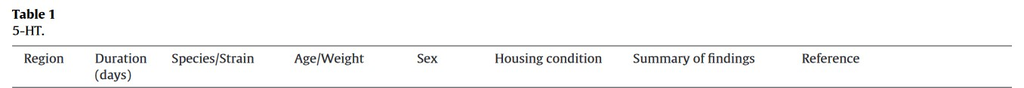

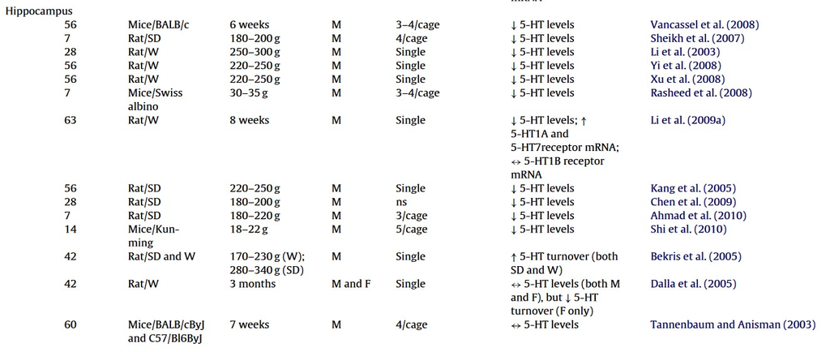

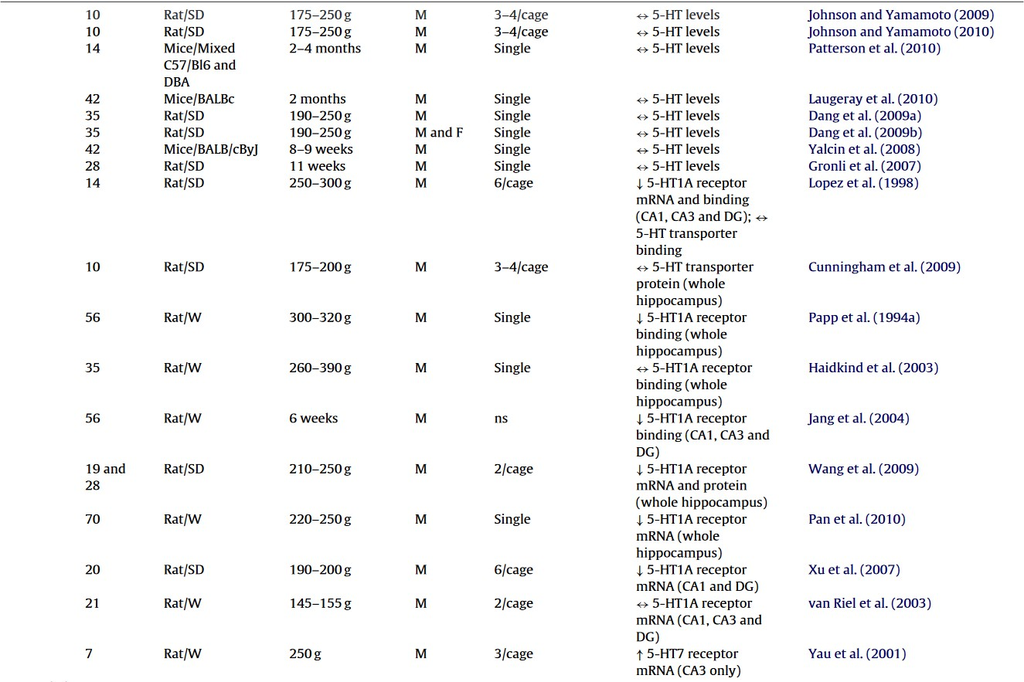

##### 1.1.2.6.1 Efectos sobre cognición

El CUM tiene efectos sobre varios aspectos de la Cognición (habilidad de procesar información, valorarla y utilizar el conocimiento por medio de conductas dirigidas. Aprendizaje, memoria, atención, razonamiento, sentimientos, toma de desiciones). Afecta distintos aspectos cognitivos (memoria, aprendizaje…), produciendo conductas “maladaptativas” (Bondi et al., 2008; Maramis et al., 2021).

Debido a que el Hipocampo regula distintos apectos de la cognición (flexibilidad cognitiva y aprendizaje espacial), esta estructura está intimamente relacionada con las alteraciones cognitivas producidas por el CUM (Anacker y Hen, 2017). Abundancia de receptors a glucocorticoidies en hipocampo lo hace muy sensible al estrés crónico (Lucassen et al., 2016).

Una investigación (**el-azis2022?**) evaluó el impacto del CUMS en varios tipos de memoria (entre ellas, la memoria espacial en el MWM) y el impacto que tenía sobre el hipocampo y la corteza prefrontal. Encontraron que el CUM afectaba la adquisición de la memoria espacial en el MWM. Además, encontraron características histológicas anormales en las áreas del cerebro relacionadas con la memoria (hipocampo y corteza prefrontal). En hipocampo, encontraron degeneración neuronal en CA1 y CA3.

Sin embargo, poco se ha estudiado sobre la relación de el CUM con un proceso específico de la cognición, la flexibilidad cognitiva y cómo se relaciona con el hipocampo.

## 1.2 Hipocampo

El hipocampo está implicado en diversas funciones cognitivas, incluyendo el aprendizaje contextual, la navegación, la discriminación de novedades y los procesos de memoria que surgen como resultado de la integración, separación y completación de la información proyectada y transmitida a través de sus distintas subregiones anatómicas. Por ejemplo, navegar por un nuevo entorno requiere varios procesos computacionales, como prestar atención a los puntos de referencia, mapear su organización espacial relativa al agente, fijarse en una ubicación objetivo y trazar la mejor trayectoria espacial para alcanzarla. Las subregiones del hipocampo desempeñan roles distintos clave en tales procesos computacionales. Anatómicamente, el término formación hipocampal generalmente se refiere al giro dentado (DG), el cornu ammonis (CA) y la corteza subicular. Además, CA se divide en cuatro subregiones, siendo CA1 y CA3 las más prominentes, CA2 forma una zona intermedia pequeña entre estas dos, y CA4 se considera una subregión polimórfica del DG. A pesar de la intensa investigación, comprender el papel de cada subregión hipocampal en procesos computacionales específicos y el resultado de su integración para lograr funciones cognitivas complejas ha sido un desafío y actualmente solo se entiende parcialmente (**sharpeningberdugovega2023?**).

Como demostraron (Penfield and Milner, 1958), es una estructura fundamental para la adquisición de memorias explícitas. two thirds of his hippocampi, parahippocampal cortices, entorhinal cortices, piriform cortices, and amygdalae in an attempt to cure his epilepsy. working memory and procedural memory were intact. complete tasks that require recall from short-term memory and procedural memory but not long-term episodic memory. Memoria episódica – eventos pasados de nuestra vida. Amnesia anterógrada (formar nuevas memorias). H.M.’s case helped redefine scientific views on how memories are formed and stored, establishing that memory functions are localized and not widely distributed across the cortex as previously thought (Lisman et al. 2017).

### 1.2.1 neurogénesis hipocampal adulta

La **neurogénesis hipocampal adulta** (NHA) es un fenómeno que desafía la antigua creencia que el cerebro adulto es incapaz de generar nuevas neuronas a lo largo de la vida. La implica la proliferación de células progenitoras neurales, su diferenciación en neuronas, y su integración eventual en circuitos neuronales. Este fenómeno no solo es crucial para la plasticidad cerebral y la formación de recuerdos, sino que también se ha vinculado con la regulación del estado de ánimo y la respuesta al estrés (Anacker y Hen 2017).

Altman’s pioneering studies gave the first evidence on the presence of undifferentiated cells in the granular cell layer of the dentate gyrus (DG) in the hippocampus of adult rats. The 3H-thymidine tagged cells were numerous not only in neonates and infant rats DG, but in adult rats as well (http://dx.doi.org/10.1002/cne.901240303 ; http://dx.doi.org/10.1038/207953a0). Eriksson [http://dx.doi.org/10.1038/3305], using immunohistochemical techniques postmortem, was the first to demonstrate the generation of new neurons from dividing progenitor cells in the DG of the hippocampus in human brains.

En roedores la neurogénesis adulta está bien descrita en dos zonas: y en el . En la zona subventricular, las células madre neurales se diferencian en distintos tipos de neuronas olfativas. En el giro dentado, las células madre neurales producen neuronas glutamatérgicas que se integran en la capa granular y proyectan sus axones hacia la región de CA3 del hipocampo (**denoth-lippuner2021?**).

Sin embargo, la existencia de la neurogénesis hipocampal en adultos humanos ha sido un tema controvertido en los últimos años. Por un lado, algunos estudios, como el de Sorrells et al. (2018), no han encontrado evidencia de neurogénesis en adultos. Por otro lado, investigaciones como la de (**boldrini2018?**) han llegado a la conclusión opuesta. Estas discrepancias se deben en gran medida a las diferencias en las metodologías utilizadas para detectar la neurogénesis y a las diversas interpretaciones de los resultados. Es probable que este debate continúe en los próximos años hasta que se desarrollen metodologías más precisas y confiables. Además, la creciente evidencia de diferencias en los procesos de neuroplasticidad entre distintos mamíferos sugiere que debemos ser cautelosos al extrapolar las conclusiones de estudios que analicen la NHA en roedores (que abarcan aspectos conductuales, celulares, genéticos, etc.) a implicaciones en humanos, según señalan La Rosa y Bonfanti (2018).

Más sobre humanos y otros mamíferos en (Bartkowska et al. 2022).

### 1.2.2 Ciclo neurogénico

Las células madre neurales (NSCs) generan nuevas neuronas a lo largo de la vida en el cerebro de los mamíferos. Las neuronas nacidas en la adultez moldean la función cerebra. La supervivencia y maduración de células nacidas en la adultez es un factor importante a considerar en las funciones cognitivas (**denoth-lippuner2021?**).

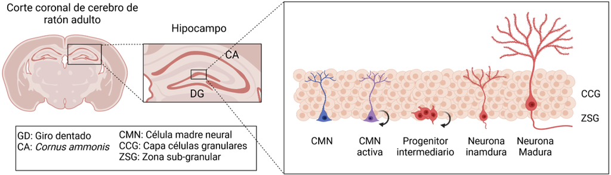

Neurogénesis Hipocampal Adulta en roedores.

Estas neuronas nacidas en la adultez se vuelven funcionalmente activas y se considera que contribuyen al aprendizaje y la memoria, especialmente durante su fase de maduración, cuando presentan una mayor plasticidad (Gonçalves, Schafer, y Gage 2016).

### 1.2.3 NHA y flexibilidad cognitiva

El estudio de la flexibilidad cognitiva tiende a enfocarse a la corteza prefrontal, aún cuando existe evidencia que otras estructuras, como el hipocampo, están involucradas. Sumado a esto, procesos del hipocampo altamente sensibles al estrés (como la neurogénesis hipocampal) también regulan aspectos relacionados a la depresión y a la flexibilidad cognitiva. Sin embargo, la relación entre estos conceptos — estrés-depresión-neurogénesis-flexibilidad cognitiva — apenas se comienza a estudiar.

La flexibilidad cognitiva es una parte importante de la **función ejecutiva**, un conjunto de habilidades cognitivas que nos permiten planificar, organizar, tomar decisiones, mantener la atención, y regular el comportamiento. Algunos elementos clave de la flexibilidad cognitiva incluyen:

• **[[Adaptabilidad**]]: La capacidad de cambiar de estrategia o enfoque en respuesta a nueva información o cambios en el entorno.

• Tolerancia a la ambigüedad: La capacidad de manejar la incertidumbre o la ambigüedad sin experimentar un estrés excesivo.

• [[Multitarea]]: La habilidad de manejar y procesar varias tareas o informaciones a la vez.

• [[Cambio de perspectiva]]: La capacidad de ver las cosas desde diferentes ángulos o puntos de vista.

• [[Pensamiento divergente]] La capacidad de generar una variedad de ideas o soluciones aun problema.

Los mecanismos exactos a través de los cuales la NHA facilita la flexibilidad cognitiva aún no se comprenden completamente., se sugiere que las terminales sinápticas de las nuevas neuronas compiten (thorny excrescences) con neuronas viejas, que pueden representar engramas viejos, hasta desplazar estructuralmente a la conexión vieja,

Facilita el reaprendizaje al inducir una degradación de engramas previos mediante la interferencia sináptica, mientras que la ausencia de nuevas neuronas impide este reaprendizaje al no eliminar los engramas viejos, lo que genera un conflicto entre engramas antiguos y nuevos (Akers et al., 2014).

las neuronas inmaduras pueden reclutar interneuronas que inhiben a las neuronas maduras del giro dentado, mientras que una baja neurogénesis mantiene una alta excitabilidad en esta región. Esta elevada excitabilidad, asociada a una baja NHA, podría resultar en una mayor activación de engramas (tanto viejos como nuevos) manifestándose como una disminución en la flexibilidad cognitiva (Anacker & Hen, 2017).

En los modelos de roedores, la parece jugar un papel crucial en los trastornos depresivos y en la regulación de la flexibilidad cognitiva. Un estudio clave que vincula la con la depresión fue realizado por A. S. Hill, Sahay, y Hen (2015). En este estudio, se incrementó la en ratones transgénicos para examinar su impacto en comportamientos de tipo depresivos y ansiosos. Esta investigación encontró que el protocolo de estrés inducía comportamientos ansiosos y depresivos, así como alteraciones en la neurogénesis. Además, descubrieron que el aumento de la era suficiente para disminuir estos síntomas depresivos y ansiosos, independientemente de cualquier regulación del eje hipotálamo-pituitario-adrenal (HPA), subrayando así el efecto significativo de la neurogénesis en las emociones.

Asimismo, se ha demostrado que tanto el ejercicio físico como los fármacos antidepresivos promueven la y la reducción de síntomas depresivos y ansiosos, tanto en modelos animales como en estudios clínicos (Anacker y Hen 2017). Adicionalmente, investigaciones en modelos murinos han establecido una conexión entre la y la flexibilidad cognitiva.

Existe evidencia que el giro dentado está involucrado en el aprendizaje revera.

En el estudio de Vilà-Balló et al. (2017), encontraron que el hipocampo es esencial para adoptar estrategias anticipatorias en el aprendizaje reversa, permitiendo una respuesta flexible a entornos de alto orden, mientras que las alteraciones en esta estructura pueden hacer que el comportamiento sea habitual e inflexible. Para esto, compararon pacientes con refractory temporal lobe epileptic patients (11 women) with unilateral hippocampal sclerosis contr individuos saludables.

Morellini et al. (2010) utilizó una glicoproteína de la matriz extracelular tenascina-R en ratones (tenascina-R) que producí un rediseño estructural y funcional del giro dentado (un aumento en la proporción de neuronas inhibitorias respecto a las excitatorias y una innervación GABAérgica mejorada). Esto resultó en una plasticidad alterada que favorece la memoria de trabajo y el aprendizaje de reversa.

Un estudio (Garthe, Behr, y Kempermann 2009) que utilizó la prueba del laberinto acuático de Morris investigó esto mediante la supresión de la neurogénesis adulta con temozolomida (TMZ). Este tratamiento condujo a un déficit de aprendizaje específico, afectando particularmente la capacidad de adaptarse a nuevas condiciones dentro de las tareas aprendidas, lo que sugiere que las nuevas neuronas en el giro dentado son cruciales para el aprendizaje y la memoria espacial flexibles y precisos. Los resultados concuerdan con la hipótesis de que el giro dentado contribuye no solo a un mapa configuracional del entorno sino que desempeña un papel crítico en los procesos de aprendizaje dinámicos, destacando un impacto significativo de la neurogénesis adulta en la plasticidad hipocampal.

Involvement of hippocampus in the ability of rats and mice to solve the water maze by constructing an allocentric spatial map has been well established (Eichenbaum et al. 1990) en Shah et al. (2019).

En este sentido, estudiar cómo la neurogénesis hipocampal adulta regula la flexibilidad cognitiva podría representar un enfoque terapéutico prometedor en los trastornos de depresión (Anacker y Hen 2017).

- Ver revisión de Deng, Aimone, y Gage (2010)
- ver Toni y Sultan (2011)

### 1.2.4 Laberinto acuático de Morris

La relación entre neurogénesis y flexibilidad cognitiva se puede estudiar mediante el uso del laberinto acuático de Morris y un protocolo de aprendizaje reversa. El laberinto acuático de Morris, junto con la prueba de condicionamiento contextual al miedo, es una de las herramientas más empleadas para evaluar la memoria y el aprendizaje episódico dependientes del hipocampo (Hernández-Mercado y Zepeda 2022).

El laberinto acuático de Morris representa el estándar de facto para probar la función del hipocampo en roedores de laboratorio. Sin embargo, en el campo de la neurogénesis hipocampal adulta, el uso de este paradigma para evaluar la relevancia funcional de las nuevas neuronas ha dado resultados sorprendentemente inconsistentes (Garthe y Kempermann 2013). Existe una inconsistencia en los resultados debido a la diversidad en los protocolos, configuraciones experimentales y análisis estadísticos. Muchos autores han expresado sus preocupaciones sobre cómo los parámetros clásicos de medición en el laberinto pueden no ser adecuados para identificar los cambios funcionales específicos generados por la modulación de la neurogénesis hipocampal adulta. En este sentido, existe una necesidad de parámetros más específicos y sensibles que reflejen la funcionalidad única del hipocampo.

En este laberinto, la flexibilidad cognitiva se estudia a través de un “aprendizaje reversa”, donde se evalúa la capacidad de reaprendizaje cuando la plataforma de escape se traslada a una nueva posición. Las pruebas de aprendizaje reversa son útiles para evaluar la flexibilidad cognitiva en roedores, primates no humanos y humanos (Uddin, 2021). En 2009, un estudio demostró una relación entre la función de la NHA y el desempeño en el aprendizaje reversa en el laberinto acuático de Morris (Garthe et al., 2009). Desde entonces, más investigaciones han llegado a conclusiones similares (Hernández-Mercado & Zepeda, 2022).

- Ver revisión de (Kapadia, Xu, y Sakic 2016)

##### 1.2.4.0.1 Problemáticas del MWM

In the Morris water maze task, the newborn neurons improved only the hippocampus-dependent aspects of the task performance (Dupret et al., 2008) and improved the flexible use of advanced learning strategies (Garthe et al., 2016) en Kempermann (2022)

Si bien, el es la prueba más utilizada para evaluar la función hipocampal, la forma en que se analizan las conductas y datos no siempre evalúan esta relación.

Por ejemplo, Maei et al. (2009) reportan que la mayoría de los artículos que utilizan el evalúan las pruebas con métricas no óptimas para evaluar el aprendizaje espacial. La principal razón de estudiar métricas menos sensibles (tiempo en cuadrante, conteo de cruces a localización de plataforma) sobre otras más sensibles al aprendizaje espacial (entropía, distancia media) parece ser solo por simplicidad y facilidad, más que por otra cuestión.

La importancia recalca en que utilizar mejores métricas y analisis destacan la importancia de las nuevas neuronas.

Por ejemplo, en un estudio, Garthe, Behr, y Kempermann (2009) suprimieron la neurogénesis adulta con temozolomida () en ratones y evaluaron su rendimiento en una tarea del laberinto acuático de Morris, observando un déficit de aprendizaje altamente específico. Aunque la supresión no afectó la potenciación a largo plazo () general, si redujo la contribución de las nuevas neuronas a la plasticidad. Los ratones tratados mostraron limitaciones en adoptar estrategias de búsqueda espacialmente precisas, destacando el papel crucial de las nuevas neuronas en la flexibilidad y precisión del aprendizaje espacial. Estos hallazgos subrayan la importancia de las células granulares adultas en la generación de mapas métricos del entorno y vinculan directamente la plasticidad celular del hipocampo con la funcionalidad cognitiva. Estas estrategias espaciales no son comunmente analizadas en los entrenamientos del . Tipicamente, se evalúa la latencia (tiempo que tarda en llegar a la plataforma), la cual solo es una métrica de aprendizaje en general (y puede depender de otras áreas), pero no espacial especificamente.

Sumado a esto, también existen críticas a los análisis estadísticos clásicamente utilizados.

(camilli1987; levy1978; vasey1987).

La interpretación de los datos obtenidos en el MWM es crucial para el entendimiento de los impactos cognitivos que tiene el estrés crónico.

### 1.2.5 Relación fisiológica del MWM y NHA

Discriminación, consolidación y clearance (Miller y Sahay 2019)

Los mecanismos exactos a través de los cuales la NHA facilita la flexibilidad cognitiva aún no se comprenden completamente. A nivel de engramas, se sugiere que las nuevas neuronas facilitan el reaprendizaje al inducir una degradación de engramas previos mediante la interferencia sináptica, mientras que la ausencia de nuevas neuronas impide este reaprendizaje al no eliminar los engramas viejos, lo que genera un conflicto entre engramas antiguos y nuevos (Akers et al., 2014).

Fisiológicamente, el control inhibitorio ejercido por las nuevas neuronas podría ser clave en el reaprendizaje. Las neuronas inmaduras pueden reclutar interneuronas que inhiben a las neuronas maduras del giro dentado, mientras que una baja neurogénesis mantiene una alta excitabilidad en esta región. Esta elevada excitabilidad, asociada a una baja NHA, podría resultar en una mayor activación de engramas (tanto viejos como nuevos) manifestándose como una disminución en la flexibilidad cognitiva (Anacker & Hen, 2017).

En humanos con síntomas depresivos y ansiosos, la falta de flexibilidad cognitiva se manifiesta en la presencia de pensamientos negativos recurrentes y persistentes (engramas viejos), así como en la ansiedad generalizada en diferentes contextos (Uddin, 2021). Por otro lado, la flexibilidad cognitiva está asociada con una mejora de estos síntomas, facilitando el enfrentamiento de problemas desde diferentes enfoques o permitiendo el reaprendizaje de experiencias negativas desde una perspectiva de autocompasión (engramas nuevos) (Güler, 2022). Comprender cómo ciertos tratamientos, como los fármacos antidepresivos, pueden mejorar la flexibilidad cognitiva y la neurogénesis hipocampal es fundamental no solo para aliviar los síntomas emocionales de la depresión, sino también para restaurar y mejorar la función cognitiva.

## 1.3 Fármacos Antidepresivos

### 1.3.1 Historia

Los primeros antidepresivos desarrollados fueron los inhibidores de la monoamino oxidasa, que mejoraban el ánimo a costa de efectos secundarios importantes, como toxicidad hepática y crisis hipertensivas. Posteriormente, se desarrollaron los antidepresivos tricíclicos (ATCs) como la imipramina y la clomipramina, que actúan principalmente bloqueando la recaptación de serotonina y noradrenalina. Debido a su falta de especificidad y efectos secundarios, los ATCs se prescriben actualmente para casos muy particulares de depresión. A finales de los años 80, surgieron los antidepresivos de segunda generación, incluyendo los inhibidores selectivos de la recaptación de serotonina (ISRS), los inhibidores de la recaptación de serotonina y noradrenalina (IRSN), antidepresivos serotonérgicos específicos y otros fármacos relacionados. Los ISRS, como el escitalopram, la fluoxetina y la sertralina, son los medicamentos más recetados para los trastornos de depresión y ansiedad, siendo la primera línea farmacológica debido a su tolerabilidad y eficacia.

### 1.3.2 Uso actual

Actualmente, la depresión es tratada farmacológicamente utilizando medicamentos conocidos como “Inhibidores Selectivos de la Recaptura de Serotonina” (ISRS). Su mecanismo de acción inmediato es a través de la regularización del sistema serotoninérgico mediante el incremento de la concentración de serotonina en el espacio sináptico. Sin embargo, su mecanismo de acción antidepresiva parece involucrar otros mecanismos, como la neurogénesis hipocampal adulta (Haroon et al., 2017).

Además, los ISRS se utilizan en el tratamiento del trastorno de pánico y el trastorno obsesivo-compulsivo. Sin embargo, tienen la desventaja de generar efectos terapéuticos semanas o meses posteriores al inicio de su tratamiento, tener una efectividad comprometida, y un 70% de los pacientes responden de manera incompleta a los ISRS, siendo el resto difícil de tratar (pacientes con depresión resistente a los fármacos) (Lin et al., 2023).

### 1.3.3 Problemáticas

Los tratamientos farmacológicos contra la depresión que se utilizan en el presente presentan varias problemáticas:

• Resistencia al tratamiento: Una proporción significativa de personas con depresión no responden adecuadamente a los antidepresivos disponibles en la actualidad. Se estima que alrededor del 30-60% de los individuos con depresión sufren de lo que se conoce como depresión resistente al tratamiento, donde dos o más antidepresivos han fallado en aliviar adecuadamente los síntomas.

• Efectos secundarios: Los medicamentos antidepresivos actuales pueden tener una variedad de efectos secundarios, algunos de los cuales pueden ser graves o intolerables para ciertos individuos. Estos pueden incluir problemas sexuales, aumento de peso, insomnio, náuseas, sequedad de boca, y más. Un medicamento que tenga menos o más leves efectos secundarios sería valioso.

• Inicio de la acción: Muchos antidepresivos actuales tardan semanas en comenzar a tener un efecto. Esto puede ser difícil para las personas que sufren de depresión, ya que necesitan alivio inmediato de sus síntomas. Los medicamentos que actúan más rápidamente podrían proporcionar un alivio más rápido.

• Diversidad de mecanismos de acción: Los medicamentos antidepresivos existentes se dirigen principalmente a los neurotransmisores serotonina, norepinefrina y, en menor medida, dopamina. Sin embargo, está claro que la depresión implica una amplia gama de sistemas y procesos biológicos, y hay otros objetivos potenciales para los medicamentos antidepresivos que aún no se han explorado plenamente.

- 60-70% de los pacientes no experimentan remisión clínica (continúan experimentando síntomas depresivos después de semanas de tratamiento).
  - Evaluada con escalas de severidad (ej *Hamilton Rating Scale for Depression*) (**Zimmerman2006?**) . Estudio más grande sobre antidepresivos (STAR*D) utilizó un protocolo de HRSD que DUPLICÓ los estimados de remisión de los pacientes (Pigott et al. 2023)

Parece que la falta de efectividad proviene del desconocimiento del mecanismo de acción de estos fármacos. Aunque algunos autores han comparado su eficacia con placebos. (**Kirsch2019?**) El grupo de Albani propone que hay un poco entendimiento de las vías involucradas en su mecanismo: (conductuales, neurogénesis, BDNF, HPA, LTP). Hipótesis de suceptibilidad unidireccional al cambio. Antidepresivos no cambian el estado de ánimo por sí mismos. Crean una ventana de oportunidad para el cambio. Esta a su vez puede ser influenciada por el ambiente, positivo o negativo (**branchi2011b?**).

### 1.3.4 Mecanismo de acción

Como se mencionó previamente, varias terapias que en modelos murinos incrementan la neurogénesis (ejercicio aeróbico, fármacos antidepresivos, modelos transgénicos) parecen también reducir los síntomas depresivos (Anacker & Hen, 2017). Varios fármacos antidepresivos (clásicos y no clásicos) podrían mitigar síntomas depresivos promoviendo la neurogénesis hipocampal, aunque podrían existir otros mecanismos de acción adicionales que contribuyan a esta acción (como efectos anti inflamatorios) (Hovorka et al., 2022).

Como se ha mencionado antes, estos fármacos podrían tener efectos sobre la plasticidad del hipocampo que faciliten la recuperación de síntomas depresivos y promuevan la flexibilidad cognitiva. Por ejemplo, el tratamiento crónico con fluoxetina (ISRS y agonista parcial de 5-HT2B) (Lin et al., 2023) promueve la neurogénesis hipocampal y reduce las conductas depresivas en modelos murinos de estrés (Segi-Nishida, 2017). Sumado a estos efectos, se ha observado que el tratamiento crónico con fluoxetina promueve la flexibilidad cognitiva en ratones en una prueba conductual que involucra discriminación de patrones espaciales (hipocampo), búsqueda de recompensa y evitación de castigos (Marwari & Dawe, 2018).

Por último, hay que destacar que utilizando técnicas de inmunohistoquímica y electrofisiología en ratones (Kobayashi et al., 2010) y primates (Callithrix jacchus) (Ohira et al., 2019), se han descrito otros procesos de plasticidad hipocampal inducidos por antidepresivos que podrían jugar un papel sobre la flexibilidad cognitiva. Estos grupos han descrito que la fluoxetina puede revertir a neuronas granulares maduras del hipocampo a un fenotipo inmaduro, un fenómeno denominado “demaduración”. Al mismo tiempo, este fármaco parece reducir el número de neuronas con redes perineuronales en el giro dentado, un fenómeno que promueve la plasticidad en el cerebro adulto.

En conjunto, estos resultados podrían significar que existen otros mecanismos independientes de la NHA que reinstauren un estado de inmadurez al giro dentado que representa un sustrato importante en la cognición y regulación del comportamiento (Umemori et al., 2018).

### 1.3.5 Fluoxetina

Es e; antidepresivo más recetado entre los adolescentes (Kryst, Majcher-Maślanka, y Chocyk 2022).

# 2 Antecedentes

## 2.1 Hipocampo es sensible al estrés crónico y depresión

Postmortem – volumen de hipocampo correlaciona con persistencia de trastorno depresivo (Cobb et al., 2013)

Resonancia magnética de alto campo: pacientes con trastorno depresivo NO medicadas tienen un menor volumen de GD, CA1 y CA3 (Huang et al., 2013).

En este estudio, se incrementó la NHA en ratones transgénicos para examinar su impacto en comportamientos de tipo depresivos y ansiosos. Los investigadores encontraron que el protocolo de estrés inducía comportamientos ansiosos y depresivos, así como alteraciones en la neurogénesis. Además, descubrieron que el aumento de la NHA era suficiente para disminuir estos síntomas depresivos y ansiosos, independientemente de cualquier regulación del eje hipotálamo-pituitario-adrenal (HPA), subrayando así el efecto significativo de la neurogénesis en las emociones. Asimismo, se ha demostrado que tanto el ejercicio físico como los fármacos antidepresivos promueven la NHA y la reducción de síntomas depresivos y ansiosos, tanto en modelos animales como en estudios clínicos (Anacker & Hen, 2017).

Bax (pro apoptótico) se elimina de manera inducible (TAM) de las células madre neurales y progiene de ratones adultos

aumenta NHA, pero no afecta conductas depresivas/ansiosas [OF, EPM, TST]

### 2.1.1 NHA está directamente involucrada con las conductas de tipo depresivas-ansiosas

(**hill2015a?**)

Estrés crónico afecta NHA e induce conductas de tipo ansiosas-depresivas.

Antidepresivos aumentan NHA, pero tienen otros efectos

Vincular directamente NHA con conductas de tipo ansioso-depresivas.

En este estudio, se incrementó la NHA en ratones transgénicos para examinar su impacto en comportamientos de tipo depresivos y ansiosos. Los investigadores encontraron que el protocolo de estrés inducía comportamientos ansiosos y depresivos, así como alteraciones en la neurogénesis. Además, descubrieron que el aumento de la NHA era suficiente para disminuir estos síntomas depresivos y ansiosos, independientemente de cualquier regulación del eje hipotálamo-pituitario-adrenal (HPA), subrayando así el efecto significativo de la neurogénesis en las emociones. Asimismo, se ha demostrado que tanto el ejercicio físico como los fármacos antidepresivos promueven la NHA y la reducción de síntomas depresivos y ansiosos, tanto en modelos animales como en estudios clínicos (Anacker & Hen, 2017).

Bax (pro apoptótico) se elimina de manera inducible (TAM) de las células madre neurales y progiene de ratones adultos

aumenta NHA, pero no afecta conductas depresivas/ansiosas [OF, EPM, TST]

Aumentar NHA no afecta respuesta del eje HPA en respuesta al estrés crónico

### 2.1.2 NHA y Cognición

Aprendizaje, memoria y olvido (Akers y Martínez-Canabal, 2014) y Epp

- Akers Science - increasing neurogenesis after the formation of a memory was sufficient to induce forgetting in adult mice

Reconocer contextos aversivos (Martínez-Canabal et al., 2019)

- Martínez 2019 - Scientific Reports – aumentar NHA previene recuperación de conductas de miedo asociadas a un contexto.

  We found that enhancing neurogenesis after, but not before, extinction prevented fear recovery. In contrast, neurogenesis ablation after, but not before, extinction promoted fear recovery. Using the neuronal activity marker c-Fos, we identified brain regions recruited in these opposing neurogenesis-mediated changes during fear recovery. together, our findings indicate that neurogenesis manipulation after extinction learning modifies fear recovery by recruiting brain network activity that mediates the expression of preexisting contextual fear and extinction memories.

Flexibilidad cognitiva (Anacker y Hen, 2017) y Aprendizaje espacial (Garthe, 2009)

## 2.2 Antidepresivos y NHA

Un estudio investigó si los ISRS y los antidepresivos tricíclicos (ATC) incrementaban los progenitores neurales (NPCs) y las células en división en el giro dentado (DG) humano en individuos con trastorno depresivo mayor (MDD). Se utilizaron hipocampos completos congelados de sujetos no tratados con MDD (N=5), tratados con antidepresivos (MDDT, N=7) y controles (C, N=7), los cuales fueron fijados, seccionados e inmunoteñidos para marcadores de NPCs y células en división (nestina y Ki-67, respectivamente), NeuN y GFAP, en etiquetado simple y doble. Los números de NPCs y células en división en el DG se estimaron mediante estereología. Se obtuvieron datos clínicos mediante autopsia psicológica y exámenes toxicológicos y neuropatológicos en todos los sujetos. Los NPCs disminuyeron con la edad (p=0.034) y las mujeres tenían más NPCs que los hombres (p=0.023). Corrigiendo por edad y sexo, los MDDT tratados con ISRS tenían más NPCs que los MDD no tratados. Parece que los antidepresivos aumentan el número de NPC en el GD anterior de los humanos, aunque queda la duda si este fenómeno es crítico o necesario para el efecto antidepresivo (Boldrini et al. 2009).

- (Malberg et al. 2000)

## 2.3 Antidepresivos y Flexibilidad Cognitiva

El estudio investigó los efectos de los enantiómeros (R) y (S) de la fluoxetina en paradigmas de comportamiento cognitivo y proliferación celular en el hipocampo de ratones hembra C57BL/6J. En una tarea de secuenciación conductual, los ratones tratados con (R)-fluoxetina mostraron una rápida adquisición de secuenciación conductual y flexibilidad cognitiva en etapas de aprendizaje reversa, en comparación con (S)-fluoxetina. Además, (R)-fluoxetina incrementó la proliferación celular en el hipocampo, especialmente en la lámina suprapiramidal del giro dentado. (R)-fluoxetina también mostró efectos superiores en pruebas de laberinto elevado más cruz, natación forzada y suspensión de cola. Estos resultados sugieren que (R)-fluoxetina, con una vida media más corta que (S)-fluoxetina, tiene efectos antidepresivos superiores y mejora de manera más consistente el aprendizaje y la memoria espacial (Marwari y Dawe 2018).

## 2.4 Análisis de datos

El correcto modelamiento de factores de riesgo en la depresión puede mejorar la predicción de la progresión clínica a tratamientos en la depresión, haciendo posible identificar mejores terapias individuales o sujetos con mayor riesgo de prevalencia de trastorno depresivo mayor. Las inferencias estadísticas tradicionales (modelos lineales) son deficientes para identificar las interacciones conductuales complejas entre fenómenos como el estrés, depresión y flexibilidad cognitiva (Utilizing Random Effects Machine Learning Algorithms for Identifying Vulnerability to Depression).

## 2.5 Resumen

- Estrés crónico afecta NHA e induce conductas de tipo ansiosas-depresivas.
- Terapias Antidepresivas aumentan NHA
- ¿qué procesos cognitivos afecta el estrés crónico y cuál es su relación con la NHA?

# 3 Pregunta de Investigación

¿Cómo influye la fluoxetina en la flexibilidad cognitiva dependiente del hipocampo en modelos de ratones con estrés crónico, y de qué manera las técnicas de análisis estadístico avanzadas pueden modelar mejor esta relación?

# 4 Hipótesis

La administración de fluoxetina mejora significativamente la flexibilidad cognitiva dependiente del hipocampo en ratones sometidos a estrés crónico. Además, el uso de técnicas de análisis estadístico avanzadas proporciona una modelación más precisa y detallada de esta relación, permitiendo una mejor comprensión de los mecanismos subyacentes y la eficacia de la intervención, en comparación con los métodos estadísticos tradicionales.

# 5 Objetivos

## 5.1 General

Evaluar el impacto de la fluoxetina sobre la flexibilidad cognitiva en ratones con estrés crónico y determinar cómo las técnicas avanzadas de análisis estadístico pueden mejorar la modelación de esta relación.

### 5.1.1 Específico 1

Investigar los efectos del estrés crónico y el tratamiento con fluoxetina sobre la flexibilidad cognitiva dependiente del hipocampo, utilizando el Laberinto Acuático de Morris.

### 5.1.2 Específico 2

Aplicar y comparar técnicas avanzadas de análisis estadístico para modelar la relación entre el estrés crónico, la administración de fluoxetina y la flexibilidad cognitiva, superando las limitaciones de los métodos estadísticos tradicionales.

Debido a las limitaciones de los enfoques actuales para analizar la relación entre flexibilidad cognitiva, aprendizaje espacial y estrés crónico, el enfoque de este estudio es demostrar la apliación y beneficios de los analisis novedosos en el contexto de estrés crónico y la función cognitiva en ratones utilizando fluoxetina.

Al emplear metodologías más robustas, esta investigación no solo busca comparar los paradigmas tradicionales con los nuevos, sino también contribuir a un mejor entendimiento de los efectos que tiene el estrés crónico y sus implicaciones para modelos teóricos e intervenciones terapéuticas.

### 5.1.3 Específico 3

Analizar la capacidad de los métodos avanzados para acomodar variabilidad individual y estructuras jerárquicas en los datos experimentales.

### 5.1.4 Específico 4

Contribuir al desarrollo de modelos más efectivos en neurociencia cognitiva que faciliten la comprensión de los mecanismos por los cuales la fluoxetina puede mitigar las alteraciones cognitivas causadas por el estrés.

# 6 Metodología

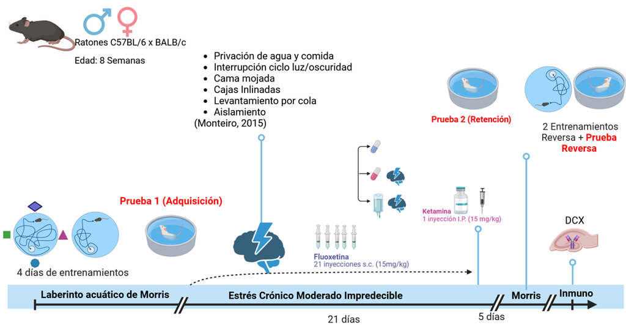

Diseño Experimental

## 6.1 Animales

Todos los ratones a utilizar en este experimento se obtendrán a partir de la cruza de ratones macho de la cepa C57BL/6 y hembras de la cepa BALB/c. Estos pies de cría se obtendrán del bioterio de la Facultad de Ciencias, UNAM, donde se tiene el convenio con la Comisión de tica Académica y Responsabilidad Científica (CEARC) con Folio:PI_2020_12_03

Hembras y machos

### 6.1.1 Cálculo de N

Se realizó un experimento piloto con las mismas condiciones y equipos que se utilizarán en el experimento final. Para el piloto, se utilizó una n=4 por grupo. Los resultados indican una diferencia de medias entre los grupos. Además, el piloto indica que los animales tratados con los fármacos aprenden tan bien las tareas como los animales controles. Esto es un signo de que los animales inyectados no están sufriendo de estrés y/o ansiedad con estos fármacos, ya que los estresores disminuyen la capacidad de aprendizaje en estas pruebas [9].

Por este motivo, solicitamos realizar el experimento con N = 8 por grupo, y en caso de no obtener resultados significativos, pero sí una tendencia clara, poder incrementar la N a 11 como límite máximo.

### 6.1.2 Mantenimiento de Animales

Los animales se mantienen de manera constante en cajas comunales de acrílico con rejilla de acero inoxidable, son mantenidos a temperatura ambiente controlada de 20°C controlada por termostato y un calentador ambiental eléctrico de aceite. La humedad ambiental se regula mediante un humidificador y se mantiene alrededor de 50%, con un ciclo de luz/oscuridad de 12:12. Los ratones se mantienen en una cama mezcla de viruta comercial para roedores con ocote molido de grano fino para ratones en una mezcla de 1:1, esto con el fin de darles una cama cómoda (viruta) pero con capacidad extra de absorción de agua y amoniaco (ocote). El alimento es ad libitum (LabDiet - 5001). Los animales se cambian de cama y se lavan sus cajas dos veces por semana. Se mantienen en colonias de entre 2 y 5 animales. Adicionalmente se les coloca material de enriquecimiento y nidificación (como tubos de cartón y papel picado) dentro de sus cajas.

## 6.2 CUM

Los ratones serán sometidos a un protocolo de estrés crónico moderado impredecible (conocido como CUMS en la literatura) durante 21 días para generar un estado depresivo. Los estresores que se utilizarán en el protocolo de estrés crónico moderado impredecible son los siguientes:

• Privación de agua y comida (8 horas)

• Interrupción ciclo luz/oscuridad.

• Cama mojada (200ml en 100g de aserrín por 19hrs)

• Cajas inclinadas a 45 grados por 24 horas

• Levantamiento por la cola (5 minutos)

• Asilamiento en cajas individuales (2 horas)

Este protocolo está basado en el trabajo de Monteiro (Monteiro et al., 2015) y representa una forma confiable de inducir estados de tipo depresivos y ansiosos en ratones C57BL/6. De acuerdo a la revisión de Svitlana Antoniuk (Antoniuk et al., 2019), este tipo de estrés crónico reduce la neurogénesis hipocampal en roedores.

Ver

- (Willner 2017)
- (Strekalova et al. 2011)
- (Strekalova et al. 2011)
- (Markov 2022)

## 6.3 Tratamiento con Fluoxetina

Se administrará un antagonista de NMDA (Ketamina 15mg/kg) o un inhibidor de la recaptura de serotonina (Fluoxetina 15mg/kg) para observar sus efectos sobre la flexibilidad cognitiva. La ketamina se administrará una sola vez vía intraperitoneal. Por otro lado, la fluoxetina se administrará diario durante 3 semanas vía subcutánea.

Ver

- (Sawyer y Howell 2011)
- (Turner et al. 2011)

## 6.5 Perfusión

Para obtener y analizar el tejido neuronal, se sacrificarán los ratones por perfusión. Para esto, se inyectará a los ratones con pentobarbital sódico a una dosis anestésica total irreversible. Este fármaco se adquiere en farmacia veterinaria bajo receta y autorización del M.V.Z encargado del bioterio de la Facultad de Ciencias. Se utiliza la marca Pet’s Pharma® N° de Registro: Q-7972-004, la cual se diluye 1:3 en solución salina estéril (0.9%) para obtener 1ml de solución por 100g de peso del animal, que corresponde a 210 mg/kg. La inyección se administra vía intraperitoneal. Tras 3 minutos, se observa si el animal ya no muestra locomoción, reflejo del párpado ante un soplo de aire y reflejo de movimiento corporal ante la presión mecánica sobre la cola. Solo hasta que ya no se observen dichos reflejos, se procede a abrir la caja torácica y perfundir con 50 ml de solución de sacarosa al 30% y 50 ml de paraformaldehído al 3.7%. Los fluidos sobrantes (mezcla de sangre con las soluciones) se almacenan y se rotulan como desechos tóxicos y se desechan de acuerdo con los procedimientos de la comisión de desechos peligrosos de la Facultad de Ciencias. Se colecta el cerebro de los animales y el resto de los tejidos se almacenan en una bolsa etiquetada como desechos biológicos para su apropiada disposición en el congelador del bioterio de la Facultad de Ciencias, anotando número de animales y fecha en la bitácora oficial. Todos los procedimientos de perfusión se llevan a cabo bajo la campana de extracción, utilizando guantes de nitrilo, bata, cofia y mascarilla con filtro para vapores orgánicos y aldehídos. Los cerebros, fijados en paraformaldehído, son rebanados en congelación en un criostato y son almacenados en anticongelante en un congelador hasta su uso para análisis posteriores.

Para obtener y analizar el tejido neuronal, se sacrificarán los ratones por perfusión. Los cerebros, fijados en paraformaldehdo, son rebanados en congelación en un criostato y son almacenados en anticongelante en un congelador hasta su uso para análisis inmunohistoquímico.

Una vez que el cerebro del ratón está incrustado en paraformaldehido se corta en secciones muy finas con un microtomo y se coloca en un portaobjetos las secciones correspondientes al hipocampo. Para remover el paraformaldehido y rehidratar el tejido, se utiliza xileno, seguido de una serie de lavados de alcohol de concentraciones decrecientes para rehidratar el tejido. Para realizar la Inmunotinción, se añade el anticuerpo primario, que está diseñado para unirse a la protenía de interés. En nuestro caso queremos observar la expresión de doblecortina (Anticuerpo a doblecortina policlonal - HPA036121-25UL sigmaaldrich), la cual es una proteína asociada a microtúbulos que solo se expresa en células neuronales precursoras o inmaduras. Finalmente, se examina la muestra bajo un microscopio (Zeiss primostar 3) y se analiza la intensidad y localización de la tinción.

## 6.6 Modelado Estadístico

### 6.6.3 Regresión logística

### 6.6.4 Dirichlech

### 6.6.5 analisis de supervivencia

# 7 Resultados

**Ver librerías y datos**

```r
# ---- librerias ----
library(tidyverse)
library(lme4)
library(flextable)
library(effects)
library(performance)
library(sjPlot)
library(emmeans)
library(gtsummary)
library(report)
library(effectsize)
library(nlme)
# library(glmmTMB)
library(gtsummary)
library(lmerTest)
# library(rstanarm) # fit bayes and describe them
library(bayestestR) # describe bayes
library(insight)
```

**Ver datos utilizados**

```r
df_ent_pre <- read.csv("./datos/df_entrenamientos_pre.csv")
df_ent_post <- read.csv("./datos/df_entrenamientos_post.csv")
df_pruebas <- read.csv("./datos/df_pruebas.csv")
```

**Ver limpieza de datos**

```r
# ---- renombrar y Recodificar variables ----
# renombrar tratamientos
df_ent_post$tratamientos[df_ent_post$tratamientos == 'Fluoxetina-Control'] <- 'Flx'

df_ent_post$tratamientos[df_ent_post$tratamientos == 'Fluoxetina+CUMS'] <- 'Flx-CUM'

df_ent_post$tratamientos[df_ent_post$tratamientos == 'Ketamina+CUMS'] <- 'Ket-CUM'

df_ent_post$tratamientos[df_ent_post$tratamientos == 'Salina+CUMS-F'] <- 'Sal-CUM-F'

df_ent_post$tratamientos[df_ent_post$tratamientos == 'Salina+CUMS-K'] <- 'Sal-CUM-K'

# recodificar a factores
df_ent_pre$tratamientos <- as.factor(df_ent_pre$tratamientos)
df_ent_pre$id <- as.factor(df_ent_pre$id)
df_ent_pre$stage <- as.factor(df_ent_pre$stage)

df_ent_post$tratamientos <- as.factor(df_ent_post$tratamientos)
df_ent_post$id <- as.factor(df_ent_post$id)
df_ent_post$stage <- as.factor(df_ent_post$stage)

df_pruebas$tratamientos <- as.factor(df_pruebas$tratamientos)
df_pruebas$id <- as.factor(df_pruebas$id)
df_pruebas$stage <- as.factor(df_pruebas$stage)

# table(df_ent_post$tratamientos) ver tratamientos
```

## 7.1 Entrenamientos

### 7.1.1 Latencia de escape post

**Ver código**

```r
df_entpost_latencia <- df_ent_post |>
  dplyr::select(latencia, tratamientos, id, dia_completo)

sjPlot::view_df(df_entpost_latencia,
                show.frq = T, show.prc = T, show.na = T)
```

Tabla 1: Tabla df latencias post

Data frame: df_entpost_latencia

| ID | Name | Label | missings | Values | Value Labels | Freq. | % |
| --- | --- | --- | --- | --- | --- | --- | --- |
| 1 | latencia |  | 0 (0.00%) | *range: 0.1-60.0* |  |  |  |
| 2 | tratamientos |  | 0 (0.00%) |  | Flx Flx-CUM Ket-CUM Sal-CUM-F Sal-CUM-K | 48 72 80 64 71 | 14.33 21.49 23.88 19.10 21.19 |
| 3 | id |  | 0 (0.00%) |  | #5 #6 1-1 1-2 1a 2-2 3-1 3-2 3a 3b 4-1 4-2 4a CK_g1_1 CK_g1_2 <... truncated> | 8 8 8 8 8 8 8 8 8 8 8 8 8 8 8 | 2.39 2.39 2.39 2.39 2.39 2.39 2.39 2.39 2.39 2.39 2.39 2.39 2.39 2.39 2.39 |
| 4 | dia_completo |  | 0 (0.00%) | *range: 0.0-1.8* |  |  |  |

#### 7.1.1.1 Regresión bayesiana de efectos mixtos

Este parámetro mide los segundos que tardan los ratones en llegar a la plataforma en los días de entrenamiento. Hay 4 entrenamientos en la plataforma original y 2 en la plataforma reversa. Evalúa un aprendizaje general de la prueba, aunque no toma en cuenta si este aprendizaje depende del hipocampo. La latencia de escape es una de las métricas más utilizadas para evaluar el aprendizaje en el MWM (Garthe y Kempermann 2013).

Un análisis estadístico de esta prueba debería considerar los siguientes supuestos (Young y Hoane 2021):

- Considerar que los datos dentro de un mismo día para el mismo animal y los datos del mismo animal a través de los días están altamente correlacionados.
- Modelar el efecto piso para el rendimiento que crea una curvatura en la relación entre la latencia y los ensayos.
- Modelar la censura de datos que ocurre como consecuencia del valor límite (**`60 s`**). La censura subestima la media y la varianza (disminución artificial de las latencias).

Young y Hoane (2021) propusieron un modelo de *regresión censurada multinivel generalizada* de latencia. Utiliza una distribución con un mínimo de **`0`** y una cola superior larga (los datos de latencia tienen distribuciones sesgadas), como las distribuciones *gamma* y las distribuciones *Weibull*. Para predecir los datos censurados, utiliza un *marco bayesiano*.

[output not shown]

[output not shown]

[output cut: 87 more lines]

[output not shown]

[output not shown]

#### 7.1.1.2 Análisis de ssupervivencia

### 7.1.2 Estrategias de búsqueda

PENDIENTE: sacar estrategias. Podemos dividir las estrategias en egocéntricas(`0`) y alocéntricas (`1`). De esta manera podemos realizar una regresión logística.

Estrategias de búsqueda: El grupo de Garthe y Kempermann (Garthe et al., 2009) definieron patrones de búsqueda que los ratones utilizan para encontrar la plataforma durante los entrenamientos. De manera general, las han definido en 2: estrategias alocéntricas y egocéntricas. Cuando los animales utilizan estrategias alocéntricas, se basan en la relación posicional entre las señales distales alrededor de la piscina para encontrar la plataforma, independientemente de su propia posición. En cambio, en la navegación egocéntrica, el animal representa la ubicación de la plataforma utilizando señales internas que dependen de su propia posición. La navegación alocéntrica depende más de la integridad y función del hipocampo que la navegación egocéntrica. El análisis de las estrategias de búsqueda desarrolladas por los roedores durante el aprendizaje en el laberinto acuático de Morris es un parámetro adecuado para evaluar el aprendizaje espacial dependiente del hipocampo (Hernández-Mercado & Zepeda, 2022).

### 7.1.3 Eficiencia

**Ver código**

```r
df_entpost_eficiencia <- df_ent_post |>
  dplyr::select(eficiancia_so, tratamientos)

sjPlot::view_df(df_entpost_eficiencia,
                show.frq = T, show.prc = T, show.na = T)
```

Tabla 2: Tabla df eficiencia post

Data frame: df_entpost_eficiencia

| ID | Name | Label | missings | Values | Value Labels | Freq. | % |
| --- | --- | --- | --- | --- | --- | --- | --- |
| 1 | eficiancia_so |  | 80 (23.88%) | *range: 0.0-1.0* |  |  |  |
| 2 | tratamientos |  | 0 (0.00%) |  | Flx Flx-CUM Ket-CUM Sal-CUM-F Sal-CUM-K | 48 72 80 64 71 | 14.33 21.49 23.88 19.10 21.19 |

**Ver código**

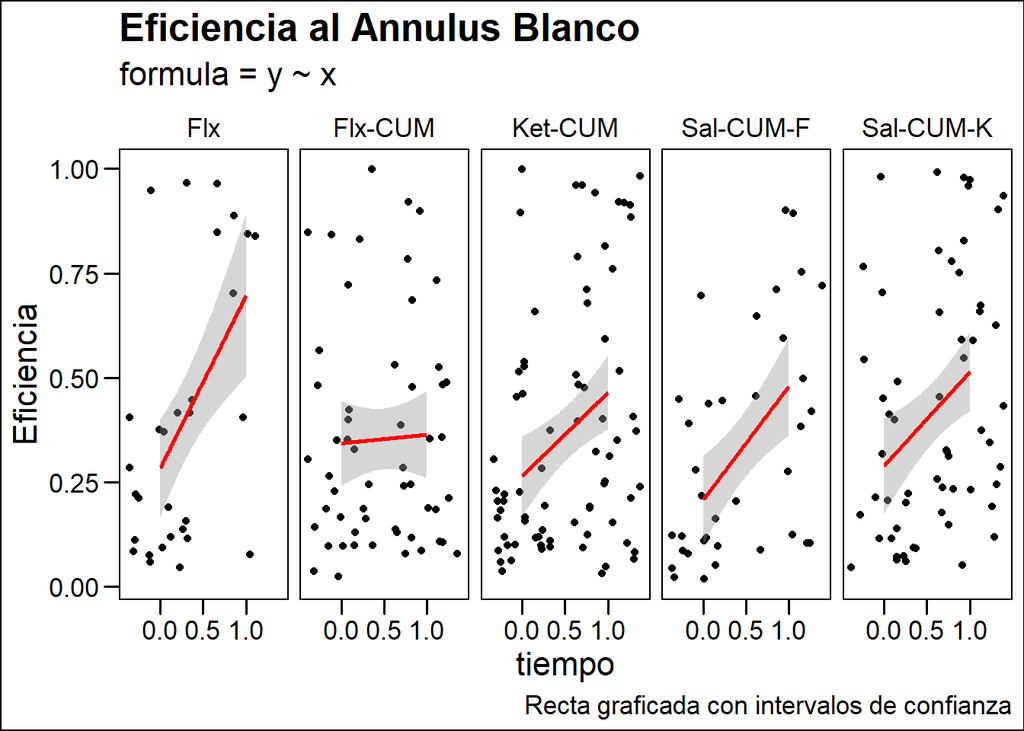

Figura 1: Eficiencia Scatter Plot

```r
ggplot(df_ent_post,
       aes(x = dia,
           y = eficiancia_so)) +
  geom_jitter()+
  geom_smooth(method = "lm", se = TRUE, color = "red") +
  labs(title = "Eficiencia al Annulus Blanco",
       subtitle = "formula = y ~ x",
       caption = "Recta graficada con intervalos de confianza",
       x = "tiempo",
       y = "Eficiencia") +
  facet_grid(~ tratamientos) +
  # theme_classic()
  ggthemes::theme_base()
```

**Ver modelado**

```r
lmer_eficiencia <- lme4::lmer(eficiancia_so ~ dia_completo * tratamientos +
                                (1 + dia_completo | id), # efectos mixtos
                              data = df_ent_post)
```

```r
equatiomatic::extract_eq(lmer_eficiencia)
```

$$\begin{aligned}
\operatorname{eficiancia\_so}_{i} &\sim N \left(\alpha_{j[i]} + \beta_{1j[i]}(\operatorname{dia\_completo}), \sigma^2 \right) \\
\left(
\begin{array}{c}
\begin{aligned}
&\alpha_{j} \\
&\beta_{1j}
\end{aligned}
\end{array}
\right)
&\sim N \left(
\left(
\begin{array}{c}
\begin{aligned}
&\gamma_{0}^{\alpha} + \gamma_{1}^{\alpha}(\operatorname{tratamientos}_{\operatorname{Flx-CUM}}) + \gamma_{2}^{\alpha}(\operatorname{tratamientos}_{\operatorname{Ket-CUM}}) + \gamma_{3}^{\alpha}(\operatorname{tratamientos}_{\operatorname{Sal-CUM-F}}) + \gamma_{4}^{\alpha}(\operatorname{tratamientos}_{\operatorname{Sal-CUM-K}}) \\
&\gamma^{\beta_{1}}_{0} + \gamma^{\beta_{1}}_{1}(\operatorname{tratamientos}_{\operatorname{Flx-CUM}}) + \gamma^{\beta_{1}}_{2}(\operatorname{tratamientos}_{\operatorname{Ket-CUM}}) + \gamma^{\beta_{1}}_{3}(\operatorname{tratamientos}_{\operatorname{Sal-CUM-F}}) + \gamma^{\beta_{1}}_{4}(\operatorname{tratamientos}_{\operatorname{Sal-CUM-K}})
\end{aligned}
\end{array}
\right)
,
\left(
\begin{array}{cc}
\sigma^2_{\alpha_{j}} & \rho_{\alpha_{j}\beta_{1j}} \\
\rho_{\beta_{1j}\alpha_{j}} & \sigma^2_{\beta_{1j}}
\end{array}
\right)
\right)
\text{, for id j = 1,} \dots \text{,J}
\end{aligned}$$

This model includes both fixed effects of time, treatment, and their interaction. Importantly, it specifies random effects for each individual represented by id where: (1 | id) specifies a random intercept for each subject. This means that each subject can have their own baseline score that differs from the population average. (time | id) specifies a random slope for time for each subject. This means that the effect of time on the test score can vary among subjects. Essentially, some subjects might improve more or less over time compared to others. Together, (1 + time | id) implies that each individual has their unique starting point (intercept) and also their unique change over time (slope), and these random intercepts and slopes are allowed to covary within each subject.

(1 + time | id) is more flexible, allowing for individual variability in both the intercept and the slope of time. This model is appropriate when you believe or need to test whether the effect of time on the test score varies from one individual to another. This might be suitable if individual trajectories are expected to differ due to unobserved factors or subject-specific responses to time.

**Ver código**

```r
sjPlot::tab_model(lmer_eficiencia,
                  # show.reflvl = T, # nivel de referencia para factores
                  # show.intercept = F,
                  p.style = "numeric_stars"
                  # title = "produccion_2009 ~ ha_maiz"
                  )
```

Tabla 3: Eficiencia resumen modelo mixtoa

|  | eficiancia so |  |  |
| --- | --- | --- | --- |
| Predictors | Estimates | CI | p |
| (Intercept) | 0.19 * | 0.03 – 0.35 | **0.022** |
| dia completo | 0.30 ** | 0.09 – 0.51 | **0.005** |
| tratamientos [Flx-CUM] | 0.17 | -0.04 – 0.38 | 0.108 |
| tratamientos [Ket-CUM] | -0.02 | -0.22 – 0.17 | 0.807 |
| tratamientos [Sal-CUM-F] | 0.03 | -0.20 – 0.26 | 0.824 |
| tratamientos [Sal-CUM-K] | 0.04 | -0.18 – 0.26 | 0.746 |
| dia completo × tratamientos [Flx-CUM] | -0.30 * | -0.55 – -0.06 | **0.016** |
| dia completo × tratamientos [Ket-CUM] | -0.08 | -0.32 – 0.16 | 0.527 |
| dia completo × tratamientos [Sal-CUM-F] | -0.17 | -0.45 – 0.10 | 0.213 |
| dia completo × tratamientos [Sal-CUM-K] | -0.10 | -0.35 – 0.15 | 0.418 |
| Random Effects |  |  |  |
| σ<sup>2</sup> | 0.07 |  |  |
| τ<sub>00</sub> <sub>id</sub> | 0.00 |  |  |
| τ<sub>11</sub> <sub>id.dia_completo</sub> | 0.00 |  |  |
| ρ<sub>01</sub> <sub>id</sub> |  |  |  |
| N <sub>id</sub> | 41 |  |  |
| Observations | 255 |  |  |
| Marginal R<sup>2</sup> / Conditional R<sup>2</sup> | 0.139 / NA |  |  |
| * p<0.05 ** p<0.01 *** p<0.001 |  |  |  |

**Ver código**

```r
# sjPlot::tab_model(lmer_eficiencia,
#                   # show.reflvl = T, # nivel de referencia para factores
#                   # show.intercept = F,
#                   p.style = "numeric_stars"
#                   # title = "produccion_2009 ~ ha_maiz"
#                   )

tbl_regression(
  lmer_eficiencia,
  add_pairwise_contrasts = T,
  pvalue_fun = ~style_pvalue(.x, digits = 3)
) %>%
  bold_p()
```

Tabla 4: Eficiencia resumen modelo mixtob

| **Characteristic** | **Beta** | **95% CI**<sup>1</sup> | **p-value** |
| --- | --- | --- | --- |
| dia_completo | 0.30 | 0.09, 0.51 |  |
| tratamientos |  |  |  |
| (Flx-CUM) - Flx | -0.10 | -0.32, 0.11 | 0.654 |
| (Ket-CUM) - Flx | -0.09 | -0.30, 0.11 | 0.695 |
| (Ket-CUM) - (Flx-CUM) | 0.01 | -0.15, 0.17 | >0.999 |
| (Sal-CUM-F) - Flx | -0.13 | -0.36, 0.10 | 0.514 |
| (Sal-CUM-F) - (Flx-CUM) | -0.03 | -0.22, 0.16 | 0.994 |
| (Sal-CUM-F) - (Ket-CUM) | -0.04 | -0.22, 0.14 | 0.979 |
| (Sal-CUM-K) - Flx | -0.06 | -0.27, 0.16 | 0.941 |
| (Sal-CUM-K) - (Flx-CUM) | 0.05 | -0.12, 0.21 | 0.929 |
| (Sal-CUM-K) - (Ket-CUM) | 0.04 | -0.12, 0.19 | 0.957 |
| (Sal-CUM-K) - (Sal-CUM-F) | 0.07 | -0.12, 0.26 | 0.800 |
| dia_completo * tratamientos |  |  |  |
| dia_completo * Flx-CUM | -0.30 | -0.55, -0.06 |  |
| dia_completo * Ket-CUM | -0.08 | -0.31, 0.16 |  |
| dia_completo * Sal-CUM-F | -0.17 | -0.45, 0.10 |  |
| dia_completo * Sal-CUM-K | -0.10 | -0.35, 0.15 |  |

<sup>1</sup> CI = Confidence Interval

```r
report::report(lmer_eficiencia)
```

```
Random effect variances not available. Returned R2 does not account for random effects.
Random effect variances not available. Returned R2 does not account for random effects.
```

```
We fitted a linear mixed model (estimated using REML and nloptwrap optimizer)
to predict eficiancia_so with dia_completo and tratamientos (formula:
eficiancia_so ~ dia_completo * tratamientos). The model included dia_completo
as random effects (formula: ~1 + dia_completo | id). The model's explanatory
power related to the fixed effects alone (marginal R2) is 0.14. The model's
intercept, corresponding to dia_completo = 0 and tratamientos = Flx, is at 0.19
(95% CI [0.03, 0.35], t(241) = 2.31, p = 0.022). Within this model:

  - The effect of dia completo is statistically significant and positive (beta =
0.30, 95% CI [0.09, 0.51], t(241) = 2.85, p = 0.005; Std. beta = 0.58, 95% CI
[0.18, 0.98])
  - The effect of tratamientos [Flx-CUM] is statistically non-significant and
positive (beta = 0.17, 95% CI [-0.04, 0.38], t(241) = 1.61, p = 0.108; Std.
beta = -0.36, 95% CI [-0.86, 0.13])
  - The effect of tratamientos [Ket-CUM] is statistically non-significant and
negative (beta = -0.02, 95% CI [-0.22, 0.17], t(241) = -0.24, p = 0.807; Std.
beta = -0.33, 95% CI [-0.80, 0.15])
  - The effect of tratamientos [Sal-CUM-F] is statistically non-significant and
positive (beta = 0.03, 95% CI [-0.20, 0.26], t(241) = 0.22, p = 0.824; Std.
beta = -0.44, 95% CI [-0.98, 0.09])
  - The effect of tratamientos [Sal-CUM-K] is statistically non-significant and
positive (beta = 0.04, 95% CI [-0.18, 0.26], t(241) = 0.32, p = 0.746; Std.
beta = -0.20, 95% CI [-0.69, 0.30])
  - The effect of dia completo × tratamientos [Flx-CUM] is statistically
significant and negative (beta = -0.30, 95% CI [-0.55, -0.06], t(241) = -2.42,
p = 0.016; Std. beta = -0.59, 95% CI [-1.06, -0.11])
  - The effect of dia completo × tratamientos [Ket-CUM] is statistically
non-significant and negative (beta = -0.08, 95% CI [-0.32, 0.16], t(241) =
-0.63, p = 0.527; Std. beta = -0.15, 95% CI [-0.61, 0.31])
  - The effect of dia completo × tratamientos [Sal-CUM-F] is statistically
non-significant and negative (beta = -0.17, 95% CI [-0.45, 0.10], t(241) =
-1.25, p = 0.213; Std. beta = -0.33, 95% CI [-0.85, 0.20])
  - The effect of dia completo × tratamientos [Sal-CUM-K] is statistically
non-significant and negative (beta = -0.10, 95% CI [-0.35, 0.15], t(241) =
-0.81, p = 0.418; Std. beta = -0.20, 95% CI [-0.69, 0.28])

Standardized parameters were obtained by fitting the model on a standardized
version of the dataset. 95% Confidence Intervals (CIs) and p-values were
computed using a Wald t-distribution approximation.
```

Supuestos del modelo

**Ver código**

```r
performance_eficiencia <- performance(lmer_eficiencia)
```

```
Random effect variances not available. Returned R2 does not account for random effects.
```

**Ver código**

```r
knitr::kable(performance_eficiencia)
```

Tabla 5: eficiencia_performance

| AIC | AICc | BIC | R2_conditional | R2_marginal | RMSE | Sigma |
| --- | --- | --- | --- | --- | --- | --- |
| 116.9554 | 118.7054 | 166.5331 | NA | 0.1387036 | 0.2559252 | 0.2658529 |

**Ver código**

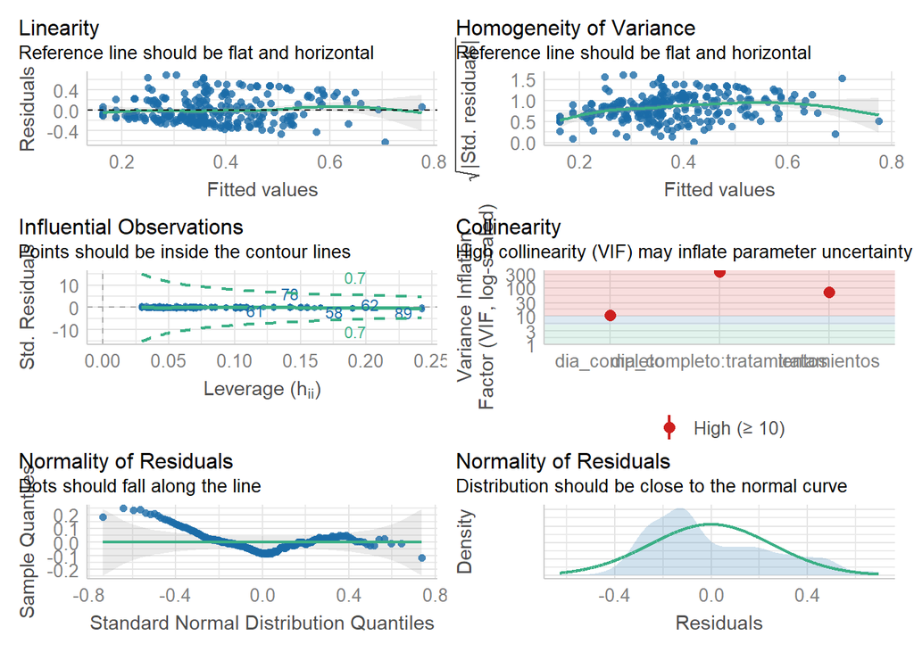

Figura 2: eficiencia_supuestos

```r
performance::check_model(lmer_eficiencia,
                         check = c("normality", "qq", "linearity", "homogeneity", "outliers", "vif"))
 # parece que no cumple del todo con los supuestos
```

## 7.2 Pruebas

El análisis de las 3 pruebas del laberinto (adquisición, retención y aprendizaje reversa) se puede realizar con distintas métricas. De acuerdo a Maei y Frankland (Maei, Zaslavsky, Teixeira, et al., 2009), las medidas más utilizadas, en orden, son: porcentaje de tiempo en cuadrante blanco (4 cuadrantes), porcentaje de tiempo en zona blanco (definida como un círculo alrededor de la localización de la plataforma) y número de cruces (cruces alrededor de la localización de la plataforma). Sin embargo, los parámetros que reflejan con mayor precisión el desempeño en estas pruebas son: distancia promedio al blanco y entropía de Shannon (Maei, Zaslavsky, Wang, et al., 2009). Esta última métrica parece ser la más sensible al aprendizaje de la prueba del laberinto acuático. Está definida como la incertidumbre con la que se conoce una variable. Esta incertidumbre reduce con información (aprendizaje). En este sentido, una certidumbre de “0” significaría que el ratón pasó todo el tiempo en la localización de la plataforma blanco. Por otro lado, si el ratón exploró todo el laberinto acuático durante la prueba, la entropía sería máxima.

### 7.2.1 Distancia Media

Como se mencionó antes, esta es una métrica mucho más sensible que las anteriores. Aquí, una menor distancia implica un mejor aprendizaje espacial. El resultado es similar: hay diferencia significativa entre el grupo control y el grupo de Ketamina+CUMS (Tukey; p=0.0158).

[output not shown]

[output cut: 40 more lines]

[output not shown]

### 7.2.2 Entropía

### 7.2.3 Porcentaje en Cuadrantes

En el análisis de porcentaje en cuadrante, la cual es una de las métricas menos sensibles, no tenemos resultados interesantes. Parece haber un olvido en la prueba 2 (retención) en todos los grupos sometidos a CUMS, aunque no hay nada significativo.

### 7.2.4 Porcentaje en Zonas

Esta es una métrica más sensible que cuadrante. De manera interesante, podemos ver que todos los grupos (excepto el control) presentan un olvido en la prueba 2 y un reaprendizaje en la prueba 3. En cuanto a la prueba 2, de manera muy interesante existe una diferencia significativa entre el grupo control y el grupo de Ketamina+CUMS (Tukey; p=0.0204, IC = -29.87199 a -1.994670). Se ha observado que aumentar la neurogénesis después de un aprendizaje puede fomentar el olvido (Martinez-Canabal, 2015), lo que en teoría facilitaría el reaprendizaje en la prueba reversa (flexibilidad cognitiva). Sin embargo, parece ser que todos los grupos tienen un reaprendizaje similar en la prueba reversa

### 7.2.5 Cruces al annulus

## 7.3 Otras

### 7.3.1 Campo abierto

Tiempo En periferia

Tiempo en Centro

### 7.3.2 Lab En Cruz

Brazos Cerrados

Brazos Abiertos

### 7.3.3 Nado Forzado

Inmovilidad Total

Inmovilidad por Minuto

### 7.3.4 Preferencia a Sacarosa

# 8 Discusión

## 8.1 Fluoxetina Revierte déficits de flexibilidad cognitiva inducidos por CUM

### 8.1.1 Flexibilidad Cognitiva

La [flexibilidad cognitiva] juega un papel importante en padecimientos mentales, incluyendo la depresión, ansiedad, autismo. Las investigaciones han mostrado que la falta de flexibilidad cognitiva puede ser un síntoma y un factor de riesgo para estos trastornos mentales.

La falta de flexibilidad cognitiva en personas con depresión puede manifestarse de varias maneras. Por ejemplo, pueden tener dificultades para adaptarse a nuevas situaciones o cambios en su vida. También pueden quedarse atrapados en patrones de pensamiento negativo ([[rumiaciones]]) y tener dificultades para ver las cosas desde diferentes perspectivas. Este tipo de pensamiento rígido puede empeorar los síntomas de la depresión y dificultar la recuperación.

Además, existe evidencia que muestra que la depresión puede afectar negativamente la flexibilidad cognitiva. Los estudios han encontrado que las personas con depresión a menudo tienen un rendimiento más pobre en tareas que requieren flexibilidad cognitiva en comparación con aquellos sujetos sin diagnóstico de depresión. Esto podría ser debido a varios factores, incluyendo la dificultad para concentrarse, la fatiga, y el pensamiento negativo asociado con la depresión. Por lo tanto, mejorar la flexibilidad cognitiva puede ser une enfoque en el tratamiento de la depresión. Las terapias [[cognitivo-conductuales]], por ejemplo, a menudo trabajan para aumentar la flexibilidad cognitiva al ayudar a los individuos a reconocer y cambiar patrones de pensamiento rígidos o negativos.

- Ver THE NEURAL BASIS OF REVERSAL LEARNING: AN UPDATED PERSPECTIVE

La NHA es importante en la separación de patrones (**clelland2009?**).

Ver

- (Cameron y Glover 2015)
- (**frança2017a?**)

denate gyrus is needed for memory maintenance. Since hyperpolarization interferes with anterograde and retrograde neuronal signaling, it is possible that the memory engram in the dentate gyrus and the entorhinal to hippocampus trisynaptic circuit was erased by long-term, but not with short-term hyperpolarization. DG output is required for memory retrieval. actively functional anterograde and retrograde neuronal signaling is necessary to preserve synaptic memory engrams along the entorhinal cortex to the hippocampal trisynaptic circuit. Carretero-Guillén, A., Treviño, M., Gómez-Climent, M.Á. et al. Dentate gyrus is needed for memory retrieval. Mol Psychiatry (2024). https://doi.org/10.1038/s41380-024-02546-0

- Other studies have found that the DG is involved in memory retrieval, but not in memory recall; however, it may be difficult to disentangle these two processes (goncalves et al., 2016).

hippocampus acts as a central hub in a dynamic hippocampal-cortical network that is recruited during episodic memory acquisition and retrieval in humans as well as rodents (Benchenane et al. 2010; Watrous et al. 2013; Nasrallah et al. 2016). The hippocampus is extensively connected to cortical and subcortical structures and during the early phases of water maze learning in rats, connectivity increases in this hippocampocentric network and other relevant brain regions (Nasrallah et al. 2016). Connections between cingulate, retrosplenial, motor, and sensory cortices appear to be particularly relevant in the cognitive processes involved in spatial learning, such as attention, coupling of spatial processing to recognition memory, decision-making, navigation, etc. (Warburton et al. 1998; Vann and Aggleton 2002, 2004; Knierim 2006; Keene and Bucci 2009; Godsil et al. 2013; Vogt and Paxinos 2014; Chersi and Burgess 2015; Pooters et al. 2017). Notably, neurons in visual cortex are known to play a role in spatial processing and exhibit location-specific firing activities that overlap with those of hippocampal neurons (Knierim 2006; Haggerty and Ji 2015). Moreover, subcortical structures such as caudate putamen and nucleus accumbens have also been found to be involved in specific stages of water maze acquisition and navigation (Mizumori et al. 2001; De Leonibus 2005; Woolley et al. 2013). en Shah et al. (2019).

It has been proposed that two control systems might be used in reversal learning. The first involves learning which actions are more optimal through direct evaluation of their rewarding consequences using prediction error signals (Sutton and Barto, 1998). The second, which arises later in time after some training, represents the subject’s belief that reversals or changes in reward contingency can occur. Thus, individuals generate a likelihood estimate that a reversal can occur, which in turn allow them to anticipate and rapidly adapt the rule change (Costa et al., 2015; Jang et al., 2015) en (**villa-ballo2017?**).

### 8.1.2 Plasticidad y NHA

### 8.1.3 NHA en humanos?

- (**adultli2023?**)
- (Dajani y Uddin 2015)
- (**dynamicsspalding2013?**) - A recent report confirmed earlier findings of neurogenesis in humans and estimated rates of neuronal birth and death by measuring the 14C content of genomic DNA in neurons from post-mortem tissue (Spalding et al., 2013).
- (Terreros-Roncal et al. 2022)
- (Zhao y Van Praag 2020)
- (Thome et al. 2017)
- quantifying neurogenesis in human subjects in vivo, even if through indirect or correlative measurements. Recent efforts in this direction, for example, using PET imaging (Tamura et al., 2016), hold significant promise.
- big unanswered question is which of these behavioral, cellular, and molecular readouts are most relevant to antidepressant action in human (10.1016/j.neuron.2009.04.017).

#### 8.1.3.1 BDNF y neurotrofinas

- (Cubillos, Engmann, y Brancato 2022)

#### 8.1.3.2 NHA en otras áreas?

- (Jurkowski et al. 2020)

### 8.1.4 Fluoxetina

Más de 20 años han generado evidencia que Fluoxetina tiene muchos efectos que regulan la NHA; proliferación de progenitores, supervivencia y maduración.

fluoxetina (ISRS y agonista parcial de 5-HT2B) (Lin et al., 2023) promueve la neurogénesis hipocampal y reduce las conductas depresivas en modelos murinos de estrés (Segi-Nishida, 2017). Sumado a estos efectos, se ha observado que el tratamiento crónico con fluoxetina promueve la flexibilidad cognitiva en ratones en una prueba conductual que involucra discriminación de patrones espaciales (hipocampo), búsqueda de recompensa y evitación de castigos (Marwari & Dawe, 2018). Por último, hay que destacar que utilizando técnicas de inmunohistoquímica y electrofisiología en ratones (Kobayashi et al., 2010) y primates (Callithrix jacchus) (Ohira et al., 2019), se han descrito otros procesos de plasticidad hipocampal inducidos por antidepresivos que podrían jugar un papel sobre la flexibilidad cognitiva. Estos grupos han descrito que la fluoxetina puede revertir a neuronas granulares maduras del hipocampo a un fenotipo inmaduro, un fenómeno denominado “demaduración”. Al mismo tiempo, este fármaco parece reducir el número de neuronas con redes perineuronales en el giro dentado, un fenómeno que promueve la plasticidad en el cerebro adulto. En conjunto, estos resultados podrían significar que existen otros mecanismos independientes de la NHA que reinstauren un estado de inmadurez al giro dentado que representa un sustrato importante en la cognición y regulación del comportamiento (Umemori et al., 2018).

Ver

- (Ohira et al. 2019)
- (Kobayashi et al. 2010)
- (Segi-Nishida 2017)
- (Hagihara et al. 2019)
- (**neurogenesisdependentdavid2009?**)

#### 8.1.4.1 Problemáticas actuales de antidepresivos

Los SSRI tienen grandes limitaciones, como un retraso en su inicio terapéutico (semanas a meses) (ver Liu B, From serotonin to neuroplasticity: evolvement of theories for major depressive disorde), un reducción en menos del 50% de los pacientes (ver Aleksandrova Antidepressant effects of ketamine and the roles of AMPA glutamate receptors and other mechanisms beyond NMDA receptor antagonism), un 33% de los pacientes tienen depresión resistente a tratamientos (al menos 2 antidepresivos son inefectivos) (ver Aleksandrova ). Debido a esto, nuevos enfoques terapéuticos deben ser buscados.

En una búsquedas sistemáticas en bases de datos electrónicas hasta el 12 de abril de 2022, se encontró que en animales naïve, la fluoxetina crónica en adolescentes produjo efectos ansiogénicos relacionados con la dosis, evidenciados por una reducción en el tiempo pasado en los brazos abiertos del laberinto elevado en cruz. No se reportaron efectos significativos de la fluoxetina en comportamientos tipo depresión en animales naïve, mientras que en roedores expuestos al estrés, la fluoxetina disminuyó significativamente el tiempo de inmovilidad en la prueba de **nado forzado** comparado con el vehículo. Estos resultados sugieren que aunque el tratamiento crónico con fluoxetina muestra efectos positivos en modelos animales de depresión, podría aumentar la ansiedad en animales adolescentes de manera relacionada con la dosis. Aunque las implicaciones clínicas de estos datos deben interpretarse con extrema precaución, se recomienda un monitoreo cercano de los pacientes adolescentes bajo tratamiento con fluoxetina (**kryst2022a?**).

Una limitación significativa de los inhibidores selectivos de la recaptación de serotonina (ISRS) es el tiempo que tardan en manifestar sus efectos positivos, que puede variar de semanas a meses. Además, hasta un tercio de los pacientes no responde a los ISRS. En contraste, la ketamina muestra efectividad pocas horas después de su primera dosis, con efectos que pueden durar hasta 3 semanas en pacientes con depresión resistente a otros tratamientos (Rawat et al., 2022). A pesar de su potencial de abuso, la ketamina no parece tener un mecanismo de adicción mediado por la señalización dopaminérgica mesolímbica, típica de las drogas de abuso clásicas (Simmler et al., 2022). Aunque el estudio de Simmler encontró que la ketamina no induce plasticidad en el núcleo accumbens ni en el área tegmental ventral, no explora otros mecanismos que expliquen la formación de un consumo de hábito que se observa en algunas personas que consumen este fármaco. Sin embargo, de manera interesante, otras investigaciones han encontrado que este fármaco induce procesos de plasticidad en áreas relacionadas con la depresión, como el hipocampo (Rawat et al., 2022).

- (**jakobsen2017?**)
- (J. Moncrieff 2018)
- https://doi.org/10.1038/s41386-024-01857-8
- (Naber y Bullinger 2018)
- (Bosman et al. 2018; Berwian et al. 2017)
- (Bosman et al. 2018)
- (Khan et al. 2012)
- (**initialkirsch2008?**)
- (Holper y Hengartner 2020)
- Falta efectos sobre microbiota. Antimicrobial activity of antidepressants on normal gut microbiota: Results of the in vitro study; Serotonin Reuptake Inhibitors and the Gut Microbiome: Significance of the Gut Microbiome in Relation to Mechanism of Action, Treatment Response, Side Effects, and Tachyphylaxis; https://gut.bmj.com/content/70/Suppl_2/A49

Cessation of therapy with a selective serotonin (5-HT) reuptake inhibitor (SSRI) is often associated with an early onset and disabling discontinuation syndrome, the mechanism of which is surprisingly little investigated (https://doi.org/10.1038/s41386-024-01857-8)

mice (once daily, 12 days. brain tissue levels of 5-HT and/or its metabolite 5-HIAA tended to decrease during continuous paroxetine, levels increased above controls after discontinuation, notably in hippocampus. depolarisation (high potassium)-evoked 5-HT release was reduced by continuous paroxetine but increased above controls post-discontinuation. Extracellular hippocampal 5-HIAA also decreased during continuous paroxetine and increased above controls post-discontinuation. paroxetine discontinuation increased c-Fos expression in midbrain 5-HT (TPH2 positive) neurons, adding further evidence for a hyperexcitable 5-HT system. behavioural experiments paroxetine discontinuation increased anxiety-like behaviour, which partially correlated in time with the measures of increased 5-HT function.

All antidepressants had an inhibitory effect on the growth of all studied microorganisms. growth activity of the normal gut microbiota individual strains. (Antimicrobial activity of antidepressants on normal gut microbiota: Results of the in vitro study). antimicrobial properties that comes with the potential of disrupting microbial hemostasis.

Disturbance to the g-b axis may be a cause of MDD

gut microbiota dysbiosis in response to antidepressants). Probiotics, prebiotics and fecal microbiota transplantation are shown to be promising strategies to ameliorate antidepressant-associated dysbiosis (https://gut.bmj.com/content/70/Suppl_2/A49).

difference of gut microbiota composition among individuals may affect the efficacy of SSRIs antidepressants (https://www.sciencedirect.com/science/article/abs/pii/S0165032723003154).

#### 8.1.4.2 Papel del sistema serotoninérgico

La hipótesis serotoninérgica de la depresión sugiere una relación entre concentraciones bajas de serotonina en el cerebro y los estados depresivos. Esta relación fue sugerida por primera vez en los sesentas y ganó relevancia en los noventas gracias al estudio de los SSRI.

Moncrieff y colaboradores %%[[moncrieff.etal_SerotoninTheoryDepression_2022]]%% realizaron una revisión sistemática umbrella y llegaron a la conclusión que no existe evidencia que respalde una asociación entre serotonina y depresión, ni evidencia de la hipótesis que bajos niveles o actividad de serotonina cause depresión. Además encontraron que el uso prolongado de antidepresivos reduce las concentraciones de serotonina %%[[moncrieff.etal_SerotoninTheoryDepression_2022#^d6ae0c]]%% %%[[moncrieff.etal_SerotoninTheoryDepression_2022#^f63a7f]]%%.

En el presente, esta hipótesis sigue siendo influyente de distintas maneras; en libros de texto que la siguen enseñando, en investigaciones que siguen tratando de buscar la relación serotonina-depresión o en la mayoría del público en general que cree que la depresión se debe a un desbalance químico. Estos factores que mantienen a esta línea de pensamiento relevante generan situaciones que dificultan el entendimiento y el tratamiento de la depresión. Por un lado, se invierten recursos en investigaciones que tratan de seguir encontrando la relación serotonina-depresión. Por otro lado, pensar que la depresión se debe a este desbalance químico genera en el público en general una idea de cómo esta entiende su humor, generando expectativas negativas sobre sus diagnósticos depresivos — se ve como más difícil regular su comportamiento si piensan que tienen un defecto biológico—. Por último, la idea que la depresión se debe a un desbalance químico (y que los SSRIs tratan esta deficiencia) también influencia en la toma de decisiones de los terapeutas y pacientes sobre el uso de medicamentos. El resultado de esta idea es que tanto pacientes como médicos se ven conflictuados en dejar los medicamentos antidepresivos, potencialmente creando una dependencia en el consumidor —%%[[moncrieff.etal_SerotoninTheoryDepression_2022#^335373]]%%

Ver

- (**latestlin2023?**)
- (**karayol2021?**)
- (**albert2019?**)
- (**zmudzka2018?**)
- (**yohn2017?**)
- (Joanna Moncrieff et al. 2022)

#### 8.1.4.3 Mecanismos independientes de NHA en SSRI

Demaduración”

Kobayashi, 2010, Ohira, 2019

↓ Calbindina, ↑ Calretinina

Sin cambios en tamaño/morfología (Impedancia de entrada/constance temporal de membrana)

PV inmaduras + remover PNN

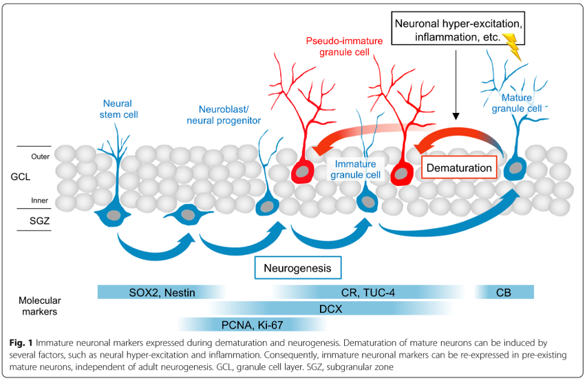

higihara, 2019

Es importante destacar que las nuevas neuronas, o neuronas inmaduras, no regulan directamente el estado de ánimo, sino que al incrementar la plasticidad neuronal, como ocurre al facilitar la neurogénesis con ISRS, se crea una ventana temporal que permite la oportunidad para el cambio. Sin embargo, este cambio inducido por la plasticidad puede ser tanto positivo como negativo.

Un estudio realizado por Alboni et al. (Alboni et al., 2017) comparó los efectos de la fluoxetina en ratones sometidos a estrés crónico en diferentes ambientes. Se observó que en un ambiente enriquecido, la fluoxetina mejoraba las conductas depresivas y ansiosas de los ratones. Por el contrario, en un ambiente no enriquecido, los ratones tratados con fluoxetina mostraban un empeoramiento en las pruebas de estrés y ansiedad en comparación con los ratones control. Esto sugiere que la plasticidad inducida por el antidepresivo hace al individuo más susceptible a la influencia del ambiente, sea este positivo o negativo. En línea con esta idea, otros autores (Moncrieff et al., 2022) hacen énfasis en no ver a los fármacos antidepresivos como sustancias que tratan un desbalance químico, sino como sustancias que facilitan procesos de plasticidad que pueden ayudar con un procesamiento adaptativo de la información con los estímulos apropiados (Branchi, 2022).

Esta observación tiene importantes implicaciones clínicas en el uso de antidepresivos. Podría explicar por qué la respuesta a los antidepresivos está relacionada con factores como el empleo, mayor ingreso económico o un nivel educativo superior (Rush et al., 2004) (Chiarotti et al., 2017). De manera similar, un estudio liderado por Jacobsen y colaboradores (Jacobsen et al., 2023), encontró que una menor flexibilidad cognitiva correlacionaba con mejoras en los síntomas depresivos y de ansiedad solo en el grupo con menor nivel educativo, mientras que en el grupo con mayor nivel educativo ocurría lo contrario. Dado que puede ser poco realista cambiar completamente el ambiente de muchos pacientes con depresión, es viable enfocarse en complementar el tratamiento farmacológico con terapias que guíen la plasticidad inducida por estos fármacos hacia resultados positivos. Un ejemplo de esto es la terapia cognitivo-conductual, la cual se enfoca en guiar de manera adaptativa los pensamientos y conductas de los pacientes (Alboni et al., 2017).

## 8.2 Métricas estándar del MWM no modelan correctamente la contribución de la NHA

Ver

- (**spatialpereira2015?**)
- (**modelingfaes2010?**)
- (Maugard, Doux, y Bonvento 2019)
  - Analysis of Compositional Data with Positive Correlations among Components using a Nested Dirichlet Distribution with Application to a Morris Water Maze Experiment - https://arxiv.org/html/2401.04841v1

### 8.2.1 Estadística

- (Reed y Kaas 2010)
- (Mayo y Hand 2022)
- (Leek y Peng 2015)
- (Johansson 2011)
- (Nakagawa y Cuthill 2007)
- (Makowski, Ben-Shachar, y Lüdecke 2019)
- (Rouder, Haaf, y Vandekerckhove 2018; Etz y Vandekerckhove 2018)
- (**reed2010a?**)
- (Shmueli 2010)

### 8.2.2 Uso de efectos mixtos

(Statistical Rethinking, McElreath, Richard): (1) To adjust estimates for repeat sampling. When more than one observation arises from the same individual, location, or time, then traditional, single-level models may mislead us.

2. To adjust estimates for imbalance in sampling. When some individuals, locations, or times are sampled more than others, we may also be misled by single-level models.
3. To study variation. If our research questions include variation among individuals or other groups within the data, then multilevel models are a big help, because they model variation explicitly.
4. To avoid averaging. Pre-averaging data to construct variables can be dangerous. Averaging removes variation, manufacturing false confidence. Multilevel models preserve the uncertainty in the original, pre-averaged values, while still using the average to make predictions.

All four apply to contexts in which the researcher recognizes clusters or groups of measurements that may differ from one another. These clusters or groups may be individuals such as different students, locations such as different cities, or times such as different years. Since each cluster may well have a different average tendency or respond differently to any treatment, clustered data often benefit from being modeled by a golem that expects such variation.(Statistical Rethinking, McElreath, Richard).

multilevel regression deserves to be the default form of regression. Papers that do not use multilevel models should have to justify not using a multilevel approach. Certainly some data and contexts do not need the multilevel treatment. But most contemporary studies in the social and natural sciences, whether experimental or not, would benefit from it.(Statistical Rethinking, McElreath, Richard).

variation in treatment effects, in which individuals or groups vary in how they respond to the same circumstance. Multilevel models attempt to quantify the extent of this variation, as well as identify which units in the data responded in which ways. itting and interpreting multilevel models can be considerably harder than fitting and interpreting a traditional regression model (Statistical Rethinking, McElreath, Richard).

Ver

- (**meteyard2022?**)
- (Luke 2017)
- (Vasey y Thayer 1987)
- (Camilli y Shepard 1987)
- (Levy 1978)
- (Schielzeth et al. 2020)
- (Bates et al. 2015)
- (Aarts et al. 2014)
- (Barr et al. 2013)
- (Vaux, Fidler, y Cumming 2012)

### 8.2.3 Bayes

Bayesian statistical inference is much older than the typical tools of introductory statistics, most of which were developed in the early twentieth century. Versions of the Bayesian approach were applied to scientific work in the late 1700s and repeatedly in the nineteenth century. But after World War I, anti-Bayesian statisticians, like Sir Ronald Fisher, succeeded in marginalizing the approach. All Fisher said about Bayesian analysis (then called inverse probability) in his influential 1925 handbook was:27 […] the theory of inverse probability is founded upon an error, and must be wholly rejected (Statistical Rethinking, McElreath, Richard).

Bayesian methods remain computationally expensive, however. And so as data sets have increased in scale—millions of rows is common in genomic analysis, for example—alternatives to or approximations to Bayesian inference remain important, and probably always will

Representa un enfoque distinto al de las pruebas de significancia de hipótesis nula.If we reject the null, we can’t really conclude that selection matters, because there are other neutral models that predict different distributions of alleles. And if we fail to reject the null, we can’t really conclude that evolution is neutral, because some selection models expect the same frequency distribution. Finding disconfirming cases is complicated by the difficulties of observation. scientists who already believe that the Ivory-billed Woodpecker is extinct will always be suspicious of a claimed falsification. Those who believe it is still alive will tend to count the vaguest evidence as falsification. whether the falsification is real or spurious. Measurement is complicated (Statistical Rethinking, McElreath, Richard).

Bayesian data analysis takes a question in the form of a model and uses logic to produce an answer in the form of probability distributions. counting the numbers of ways the data could happen, according to our assumption. preceding description doesn’t invoke anyone’s “beliefs” or subjective opinions. Bayesian data analysis is just a logical procedure for processing information. many scientists interpret non-Bayesian results in Bayesian terms, for example interpreting ordinary p-values as Bayesian posterior probabilities (Statistical Rethinking, McElreath, Richard).

believed that one always ought to perform a null hypothesis test, without exception. The researchers did not notice how small their statistical power was, nor did they seem to care: Power is not part of the null ritual that dominates experimental psychology. The essence of the ritual is the following. Set up a statistical null hypothesis of “no mean difference” or “zero correlation.” Don’t specify the predictions of your research hypothesis or of any alternative substantive hypotheses.se 5% as a convention for rejecting the null. If significant, accept your research hypothesis. he null ritual has sophisticated aspects we will not cover here, such as alpha adjustment and ANOVA procedures, but these do not change its essence. A p-value is the probability of the observed data (or of more extreme data points), given that the null hypothesis H0 is true, defined in symbols as p(D |H0). A significance test can never disprove the null hypothesis. Significance tests provide probabilities, not definite proofs. p-value is a probability of data, not of a hypothesis. Despite wishful thinking, p(D |H0) is not the same as p(H0 |D), and a significance test does not and cannot provide a probability for a hypothesis. One cannot conclude from a p-value that a hypothesis has a probability of 1 (gigerenzer, Stefan Krauss, and Oliver Vitouch).

### 8.2.4 Modelamiento múltipl

Th e Neyman-Pearson theory serves as the superego of Dr. Publish-Perish’s statistical thinking, demanding in advance the specification of precise alternative hypotheses, significance levels, and power to calculate the sample size necessary, as well as teaching the doctrine of repeated random sampling (Neyman, 1950, 1957). Moreover, the frequentist superego forbids the interpretation of levels of signifi cance as the degree of confidence that a particular hypothesis is true or false. Hypothesis testing, in its view, is about decision making (i.e., acting as if a hypothesis were true or false) but not about epistemic statements (i.e., believing in a hypothesis) (gigerenzer, Stefan Krauss, and Oliver Vitouch)..

### 8.2.5 Presentación de datos

Ver

- (Zaloumis et al. 2015)
- (Cumming, Fidler, y Vaux 2007)

## 8.3 Perpectivas y futuros estudios

### 8.3.1 Más allá de la serotonina

Otros sistemas deben de ser estudiados, como otros sitemas de neurotransmisión, BDNF, HPA, sistema inmune, gut-brain axis (**tian2022?**).

### 8.3.2 Otras áreas cerebrales de interés

- Escitalopram Restores Reversal Learning Impairments in Rats with Lesions of Orbital Frontal Cortex
- ver: Chronic Stress Alters Spatial Representation and Bursting Patterns of Place Cells in Behaving Mice

hippocampus acts as a central hub in a dynamic hippocampal-cortical network that is recruited during episodic memory acquisition and retrieval in humans as well as rodents (Benchenane et al. 2010; Watrous et al. 2013; Nasrallah et al. 2016). The hippocampus is extensively connected to cortical and subcortical structures and during the early phases of water maze learning in rats, connectivity increases in this hippocampocentric network and other relevant brain regions (Nasrallah et al. 2016). Connections between cingulate, retrosplenial, motor, and sensory cortices appear to be particularly relevant in the cognitive processes involved in spatial learning, such as attention, coupling of spatial processing to recognition memory, decision-making, navigation, etc. (Warburton et al. 1998; Vann and Aggleton 2002, 2004; Knierim 2006; Keene and Bucci 2009; Godsil et al. 2013; Vogt and Paxinos 2014; Chersi and Burgess 2015; Pooters et al. 2017). Notably, neurons in visual cortex are known to play a role in spatial processing and exhibit location-specific firing activities that overlap with those of hippocampal neurons (Knierim 2006; Haggerty and Ji 2015). Moreover, subcortical structures such as caudate putamen and nucleus accumbens have also been found to be involved in specific stages of water maze acquisition and navigation (Mizumori et al. 2001; De Leonibus 2005; Woolley et al. 2013). en Shah et al. (2019).

It has been proposed that two control systems might be used in reversal learning. The first involves learning which actions are more optimal through direct evaluation of their rewarding consequences using prediction error signals (Sutton and Barto, 1998). The second, which arises later in time after some training, represents the subject’s belief that reversals or changes in reward contingency can occur. Thus, individuals generate a likelihood estimate that a reversal can occur, which in turn allow them to anticipate and rapidly adapt the rule change (Costa et al., 2015; Jang et al., 2015) en (**villa-ballo2017?**).

Otras estructuras que son importantes en el estrés, además del hipocampo, son la amígdala y la corteza prefrontal (McEwen, Nasca, y Gray 2016).

La PFC es de suma importancia en la flexibilidad cognitiva (Park y Moghaddam 2017) y (Ji-Woon Kim et al. 2023) y (**yun2023?**) y (**kim2024?**).

Ver

- (Liu et al. 2017)

#### 8.3.2.1 Otros sistemas de neurotransmisión

Su mecanismo de acción inmediato es a través de la regularicación del sistema serotoninérgico. Sin embargo, su mecanismo de acción antidepresiva parece involucrar otros sistemas de neurotransmisión. Uno de estos sistemas indirectamente involucrados en el mecanismo de los ISRS es el [[sistema glutamatérgico]].

Además, el [[sistema glutamatérgico del cerebro juega un papel importante en la neurogénesis hipocampal]]. El glutamato es el neurotransmisor excitatorio principal en el cerebro, y su función se extiende a muchos aspectos de la neuroplasticidad, que incluye la neurogénesis.

En el hipocampo, el glutamato y sus receptores, especialmente los[[ receptores NMDA y AMPA]], están involucrados en la regulación de la formación, supervivencia y diferenciación de las nuevas neuronas. Esto se debe a que el glutamato y sus receptores juegan un papel importante en la excitación neuronal y la plasticidad sináptica, procesos que son esenciales para el funcionamiento normal de las nuevas neuronas y para la integración de estas células en las redes neuronales existentes.

Por ejemplo, se ha demostrado que la activación de los receptores NMDA en las células madre neuronales del hipocampo puede promover la neurogénesis. A la inversa, la disfunción del sistema glutamatérgico, como la sobreexcitación neuronal debido a niveles excesivos de glutamato, puede ser perjudicial para las células neuronales y puede disminuir la neurogénesis.

Cabe destacar que los investigadores también están estudiando el sistema glutamatérgico como un posible objetivo para medicamentos que podrían mejorar la neurogénesis hipocampal. Por ejemplo, algunos estudios sugieren que los medicamentos que modulan el sistema glutamatérgico, como la [ketamina], podrían tener efectos antidepresivos rápidos y pueden aumentar la neurogénesis en el hipocampo. Sin embargo, este es un campo de investigación en desarrollo, y se requieren más estudios para comprender completamente estos procesos y su relevancia para las enfermedades neurológicas y psiquiátricas.

Ver

- (Duman, Sanacora, y Krystal 2019)
- (Gerhard, Wohleb, y Duman 2016)

Antagonista de GluN2B impide aprendizaje reversa en prueba de Water Maze (Dong et al., 2012)

GluN2B-containing NMDA receptors, Taannehoiz, rene hen

fluoxetine, imipramine, and ketamine, directly bind to TrkB, facilitating BDNF action and plasticity (Casarotto et al., 2021).

##### 8.3.2.1.1 Ketamina

La ketamina — un antagonista no competitivo del receptor a glutamato NMDA —, tradicionalmente utilizada como agente anestésico, ha sido investigada en las últimas décadas por sus potenciales propiedades antidepresivas en dosis subanestésicas para tratar trastornos del estado de ánimo (Zanos & Gould, 2018). Una limitación significativa de los inhibidores selectivos de la recaptación de serotonina (ISRS) es el tiempo que tardan en manifestar sus efectos positivos, que puede variar de semanas a meses. Además, hasta un tercio de los pacientes no responde a los ISRS. En contraste, la ketamina muestra efectividad pocas horas después de su primera dosis, con efectos que pueden durar hasta 3 semanas en pacientes con depresión resistente a otros tratamientos (Rawat et al., 2022). A pesar de su potencial de abuso, la ketamina no parece tener un mecanismo de adicción mediado por la señalización dopaminérgica mesolímbica, típica de las drogas de abuso clásicas (Simmler et al., 2022). Aunque el estudio de Simmler encontró que la ketamina no induce plasticidad en el núcleo accumbens ni en el área tegmental ventral, no explora otros mecanismos que expliquen la formación de un consumo de hábito que se observa en algunas personas que consumen este fármaco. Sin embargo, de manera interesante, otras investigaciones han encontrado que este fármaco induce procesos de plasticidad en áreas relacionadas con la depresión, como el hipocampo (Rawat et al., 2022). Desde la primera evidencia clínica del uso de ketamina en pacientes con depresión (Berman et al., 2000), se ha intentado comprender su mecanismo de acción terapéutico. Estos mecanismos incluyen desde incrementos en vías celulares relacionadas con la plasticidad (BDNF, eEF2K, mTOR) hasta la regulación de receptores AMPA en la corteza prefrontal e hipocampo. Un aspecto menos estudiado es su efecto en el giro dentado. Basándose en esta idea, Rawat y colaboradores demostraron que la ketamina activa neuronas inmaduras del giro dentado 24 horas después de la inyección en un modelo de estrés en ratones (Rawat et al., 2022). Mediante manipulación quimiogenética, mostraron que esta población de neuronas inmaduras del giro dentado es crucial para la acción antidepresiva de la ketamina. A partir de estos hallazgos, surge la interesante posibilidad de que la activación rápida de neuronas inmaduras del giro dentado por la ketamina pueda facilitar la flexibilidad cognitiva (Figura 1).

La ketamina — un antagonista no competitivo del receptor a glutamato NMDA —, tradicionalmente utilizada como agente anestésico, ha sido investigada en las últimas décadas por sus potenciales propiedades antidepresivas en dosis subanestésicas para tratar trastornos del estado de ánimo (Zanos & Gould, 2018).

Desde la primera evidencia clínica del uso de ketamina en pacientes con depresión (Berman et al., 2000), se ha intentado comprender su mecanismo de acción terapéutico. Estos mecanismos incluyen desde incrementos en vías celulares relacionadas con la plasticidad (BDNF, eEF2K, mTOR) hasta la regulación de receptores AMPA en la corteza prefrontal e hipocampo. Un aspecto menos estudiado es su efecto en el giro dentado. Basándose en esta idea, Rawat y colaboradores demostraron que la ketamina activa neuronas inmaduras del giro dentado 24 horas después de la inyección en un modelo de estrés en ratones (Rawat et al., 2022). Mediante manipulación quimiogenética, mostraron que esta población de neuronas inmaduras del giro dentado es crucial para la acción antidepresiva de la ketamina. A partir de estos hallazgos, surge la interesante posibilidad de que la activación rápida de neuronas inmaduras del giro dentado por la ketamina pueda facilitar la flexibilidad cognitiva

efectividad pocas horas después de su primera dosis, con efectos que pueden durar hasta 3 semanas en pacientes con depresión resistente a otros tratamientos (Berman et al., 2000)

Aprobada por FDA en 2019

Antagonista no competitivo de NMDA

Berman - Biol Psychiatry

Hamilton Depression Rating Scale - g mood, feelings of guilt, suicide ideation, insomnia, agitation or retardation, anxiety, weight loss, and somatic symptoms

V-2 – isoniazida –tb | clorpromazina (antihistaminico)

Simmler et al., 2022 - Nature

Ver

- (Rawat et al. 2022)
  - Se conoce poco de sus efectos sobre su dinámica en Giro dentado
  - Ketamina activa neuronas inmaduras en paralelo a sus efectos antidepresivos/ansiolíticos
  - social interaction (SIT), social novelty (SNT), and tail suspension (TST)

    Efectos conductuales de ketamina se perdieron al silenciar las neuronas inamduras

    designer receptors exclusively activated by designer drugs (DREADDs)

    hM4Di – variants de receptors muscarínicos activados por CNO

    ASCL1 – diferenciación

    Supress excitability newborn neurons after they have integrated into the hippocampal circuitr

    Ratones Ascl1-Cre - hM4Di (Tunc-Ozcan et al., 2019

Ketamina tiene efectos sobre neuronas inmaduras del GD y esto está relacionado con su acción antidepresiva. Pero no hay estudios que relacionen este efecto con la flexibilidad cognitiva-memoria espacial

- (Yamada y Jinno 2019)
- (**bridgingkim2023?**)
- (**xu2022?**)
- (Hashimoto 2019)
- (Carreno, Lodge, y Frazer 2020)
- (Kraus et al. 2019)
- (Marchi et al. 2022)
- rapid increase of BDNF in the hippocampus stimulates neurogenesis in the DG, which is important for the sustained antidepressant actions of ketamine (TrkB dependent adult hippocampal progenitor differentiation mediates sustained ketamine antidepressant response).
- Ketamine seems to accelerate the maturation phase of hippocampal immature neurons, but it has less effect on the numbers of neural progenitors (Trk, B. TrkB dependent adult hippocampal progenitor differentiation mediates sustained ketamine antidepressant response, Potential link between antidepressant-like ef[87] fects of ketamine and promotion of adult neurogenesis in the ventral hippocampus of mice).
- Ly et al. [95] demonstrated how psychedelic compounds such as lysergic acid diethylamide (LSD), N,N-dimethyltryptamine (DMT), and 2,5-dimethoxy-4-iodoamphetamine (DOI) may increase dendritic arbor complexity, promote dendritic spine growth and stimulate synapse formation, thereby highlighting the potential of psychedelics for treating depression and related disorders.
- NMDA receptor antagonists also augment the release of dopamine (Moghaddam et al, 1997), glutamate, and serotonin in the medial prefrontal cortex (mPFC) of rats (**Jiménez-Sánchez2014?**)`
- ketamine rapidly accelerates BDNF expression and release through different signaling, NMDA receptor antagonism, especially on the GABAergic interneurons that control the glutamatergic activity. Subsequently, the ketamine-induced glutamate release stimulates postsynaptic AMPA, depolarization and activation of L-type voltage-dependent Ca2+ channels leading to a rapid BDNF release. addition, the ketamine NMDA receptor antagonism increases BDNF translation through the deactivation of eukaryotic elongation factor 2 (EEF2) (Carli et al., 2021). rapid increase of BDNF in the hippocampus stimulates neurogenesis in the DG, which is important for the sustained antidepressant actions of ketamine (TrkB dependent adult hippocampal progenitor differentiation mediates sustained ketamine antidepressant response). Ketamine seems to accelerate the maturation phase of hippocampal immature neurons, but it has less effect on the numbers of neural progenitors (Trk, B. TrkB dependent adult hippocampal progenitor differentiation mediates sustained ketamine antidepressant response, Potential link between antidepressant-like ef[87] fects of ketamine and promotion of adult neurogenesis in the ventral hippocampus of mice).
- Ketamine seems to accelerate the maturation phase of hippocampal immature neurons, but it has less effect on the numbers of neural progenitors (Trk, B. TrkB dependent adult hippocampal progenitor differentiation mediates sustained ketamine antidepressant response, Potential link between antidepressant-like ef[87] fects of ketamine and promotion of adult neurogenesis in the ventral hippocampus of mice).
- Ly et al. [95] demonstrated how psychedelic compounds such as lysergic acid diethylamide (LSD), N,N-dimethyltryptamine (DMT), and 2,5-dimethoxy-4-iodoamphetamine (DOI) may increase dendritic arbor complexity, promote dendritic spine growth and stimulate synapse formation, thereby highlighting the potential of psychedelics for treating depression and related disorders.

### 8.3.3 Tratamientos no farmacológicos

- (**environmentalclemenson2015?**)
- (**treatmentsduval2006?**)

### 8.3.4 Alimentación y eje GBA

- (Poulose et al. 2017)

### 8.3.5 Glia

- (Wang et al. 2022)
- (Cope y Gould 2019)

### 8.3.6 Sexo

Si bien, en humanos, la depresión se da más en mujeres, en estudios animales se suele estudiar más en machos.

Por ejemplo, el sexo parece tener un efecto en la neurogénesis hipocampal y los procesos cognitivos dependientes de esta (Yagi y Galea 2019).

Además, los fármacos antidepresivos tienen un efecto diferencial en el sexo (LeGates, Kvarta, y Thompson 2019) y (Pawluski et al. 2014)

- (**desá-calçada2015?**)

### 8.3.7 Epigenética

- (**epigeneticyao2016?**)

### 8.3.8 LPT

- Adult born - electrophysiological characteristics are initially distinct from those of mature DG neurons: they have higher input resistance, lower threshold voltage, and a slower membrane time constant and they are more prone to long-term potentiation (LTP). Since DGCs have very low firing probabilities, only a small population of DGCs is activated by these inputs at any given time, resulting in sparse representation of contexts and events. The sparseness of these DG representations—also known as ‘’engrams’’—is thought to be crucial for creating non-overlapping (or orthogonal) responses to different experiences, thereby keeping memories distinct. The sparseness of coding in the DG is largely due to strong inhibitory inputs from interneuron populations in the DG and hilus. Sparse representations in the DG are relayed to CA3, a hippocampal area characterized by recurrent connections that is hypothesized to function as an auto-association network; it has been shown to play a role in pattern completion, i.e., to recall a memory upon an incomplete cue or only a partial activation of its neuronal representation. However, CA3 is also thought to be able to perform pattern separation, and whether it performs one or the other task seems to depend on the input it receives directly from the EC and, particularly in the case of pattern separation, from the DG. implement pattern separation and pattern completion, both essential functions for episodic memory formation and recall: the former permits generalization and recall from incomplete inputs, whereas the latter ensures that similar memories are kept distinct from each other. (goncalves et al., 2016).

### 8.3.9 Cepa de ratones utilizada

Ver

- (Jong Whi Kim et al. 2018)
- (Kempermann, Kuhn, y Gage 1997)
- (Jong Whi Kim et al. 2017)
- (Crusio et al. 1990)
- (Carola et al. 2004)

## 8.4 Métodologías para el estudio de depresión

Ver

- (Planchez, Surget, y Belzung 2019)
- (Yan et al. 2010)

### 8.4.1 Preferencia a sacarosa

- (Markov 2022)

This reduction in sucrose consumption was believed to be akin to the impairments in reward processing, which are the foundation for anhedonia, a core symptom of major depression (American Psychiatric Association and American Psychiatric Association Task Force on DSM-IV, 2000) en M. N. Hill et al. (2012).

### 8.4.2 Nado forzado

- (Yankelevitch-Yahav et al. 2015; Bogdanova et al. 2013)

### 8.4.3 Campo Abierto

- (Seibenhener y Wooten 2015)

### 8.4.4 Laberinto Elevado

- (Walf y Frye 2007)

## 8.5 Discusión General

Parece que los efectos más prominentes en nuestro modelo se encuentran en la prueba 2 (retención) y en el primer día de entrenamiento reversa. En especial en el grupo de Ketamina+CUMS, parece haber un olvido en la prueba 2, además de que parece que adoptan de manera más rápida un uso de estrategias alocéntricas en las pruebas reversa. Esto pareciera ser un indicativo de flexibilidad cognitiva dependiente del hipocampo (Hernández-Mercado & Zepeda, 2022), aunque este efecto se pierde rápidamente en la prueba reversa.

Una posibilidad que explica este fenómeno es nuestro protocolo de entrenamiento reversa. Muchos estudios que evalúan la flexibilidad cognitiva en el laberinto acuático de Morris parecen utilizar más de una prueba reversa. Esta complejidad adicional parece mostrar que las nuevas neuronas del giro dentado facilitan una adaptabilidad rápida a los nuevos contextos (Garthe & Kempermann, 2013).

Por ejemplo, un trabajo reciente realizado por Amelchenko y colaboradores (Amelchenko et al., 2023) utilizó un protocolo de entrenamiento reversa seguido de un protocolo de laberinto de Morris con discriminación contextual en ratones de distintas edades. Este último paradigma introduce una complejidad que demanda al ratón diferenciar el contexto (color de la piscina) además de las pistas espaciales para localizar la plataforma correcta. El nivel de neurogénesis correlacionó con el desempeño en ambas pruebas (reversa y discriminación). Sin embargo, similar a nosotros, las diferencias en el protocolo reversa solo se observaron en el primer día de entrenamiento. Sin embargo, las diferencias en los distintos grupos de edades se hicieron evidentes con el segundo protocolo (discriminación contextual). En otro trabajo se observó como otro fármaco antagonista del receptor NMDA, memantina, empeoraba la flexibilidad cognitiva en ratones (Saab et al., 2011). Estos investigadores usaron 3 protocolos reversa cada tercer día, y observaron que la memantina empeoraba el reaprendizaje de manera gradual en cada nueva localización de la plataforma.

Estos trabajos y nuestros resultados parecen indicar que necesitamos aumentar la complejidad del aprendizaje reversa, ya sea cambiando la localización de la plataforma una segunda o tercera vez, o agregando una prueba de discriminación contextual al laberinto.

Por último, en un inicio se tenía contemplado hacer pruebas que evaluaran conductas de tipo depresivas y conductas de tipo ansiosas (Laberinto en cruz, campo abierto, nado forzado y preferencia a sacarosa). Sin embargo, estas pruebas no están enfocadas hacia mi pregunta de investigación, la cual busca responder la relación entre flexibilidad cognitiva y el uso de fármacos que alteran la plasticidad del giro dentado. Aunque podría ser interesante explorar estas pruebas, nuestro modelo parece no ser ideal. En específico, la cruza de ratones que utilizamos no es la adecuada para estas pruebas conductuales. Estas pruebas son altamente específicas para las cruzas de ratones utilizadas por factores que van desde sensibilidad a la sacarosa (Sclafani, 2006) hasta la actividad locomotora y exploratoria en estas pruebas de ansiedad/depresión (Carola et al., 2004). Estos autores sugieren utilizer ratones con un perfil genético bien definido para realizar estas pruebas.

# 9 Conclusiones

# 10 Literatura Citada

Aarts, Emmeke, Matthijs Verhage, Jesse V. Veenvliet, Conor V. Dolan, y Sophie van der Sluis. 2014. «A Solution to Dependency: Using Multilevel Analysis to Accommodate Nested Data». *Nature Neuroscience* 17 (4): 491-96. https://doi.org/10.1038/nn.3648.

Anacker, Christoph, y René Hen. 2017. «Adult Hippocampal Neurogenesis and Cognitive Flexibility — Linking Memory and Mood». *Nature Reviews Neuroscience* 18 (6): 335-46. https://doi.org/10.1038/nrn.2017.45.

Barr, Dale J., Roger Levy, Christoph Scheepers, y Harry J. Tily. 2013. «Random Effects Structure for Confirmatory Hypothesis Testing: Keep It Maximal». *Journal of Memory and Language* 68 (3): 255-78. https://doi.org/10.1016/j.jml.2012.11.001.

Bartkowska, Katarzyna, Beata Tepper, Krzysztof Turlejski, y Ruzanna Djavadian. 2022. «Postnatal and Adult Neurogenesis in Mammals, Including Marsupials». *Cells* 11 (17): 2735. https://doi.org/10.3390/cells11172735.

Bates, Douglas, Martin Mächler, Ben Bolker, y Steve Walker. 2015. «Fitting Linear Mixed-Effects Models Using Lme4». *Journal of Statistical Software* 67 (octubre): 1-48. https://doi.org/10.18637/jss.v067.i01.

Berwian, I. M., H. Walter, E. Seifritz, y Q. J. M. Huys. 2017. «Predicting Relapse After Antidepressant Withdrawal – a Systematic Review». *Psychological Medicine* 47 (3): 426-37. https://doi.org/10.1017/S0033291716002580.

Bogdanova, Olena V., Shami Kanekar, Kristen E. D’Anci, y Perry F. Renshaw. 2013. «Factors Influencing Behavior in the Forced Swim Test». *Physiology & Behavior* 118 (junio): 227-39. https://doi.org/10.1016/j.physbeh.2013.05.012.

Boldrini, Maura, Mark D. Underwood, René Hen, Gorazd B. Rosoklija, Andrew J. Dwork, J. John Mann, y Victoria Arango. 2009. «Antidepressants Increase Neural Progenitor Cells in the Human Hippocampus». *Neuropsychopharmacology* 34 (11, 11): 2376-89. https://doi.org/10.1038/npp.2009.75.

Bosman, Renske C., Ruth C. Waumans, Gabriel E. Jacobs, Richard C. Oude Voshaar, Anna D.T. Muntingh, Neeltje M. Batelaan, y Anton J.L. M. van Balkom. 2018. «Failure to Respond After Reinstatement of Antidepressant Medication: A Systematic Review». *Psychotherapy and Psychosomatics* 87 (5): 268-75. https://doi.org/10.1159/000491550.

Cameron, Heather A., y Lucas R. Glover. 2015. «Adult Neurogenesis: Beyond Learning and Memory». *Annual Review of Psychology* 66 (1): 53-81. https://doi.org/10.1146/annurev-psych-010814-015006.

Camilli, Gregory, y Lorrie A. Shepard. 1987. «The Inadequacy of ANOVA for Detecting Test Bias». *Journal of Educational Statistics* 12 (1): 87-99. https://doi.org/10.3102/10769986012001087.

Carola, Valeria, Francesca D’Olimpio, Emiliano Brunamonti, Arturo Bevilacqua, Paolo Renzi, y Franco Mangia. 2004. «Anxiety-Related Behaviour in C57BL/6↔︎BALB/c Chimeric Mice». *Behavioural Brain Research* 150 (1): 25-32. https://doi.org/10.1016/S0166-4328(03)00217-1.

Carreno, Flavia R., Daniel J. Lodge, y Alan Frazer. 2020. «Ketamine: Leading Us into the Future for Development of Antidepressants». *Behavioural Brain Research* 383 (abril): 112532. https://doi.org/10.1016/j.bbr.2020.112532.

Cope, Elise C., y Elizabeth Gould. 2019. «Adult Neurogenesis, Glia, and the Extracellular Matrix». *Cell Stem Cell* 24 (5): 690-705. https://doi.org/10.1016/j.stem.2019.03.023.

Crusio, Wim E., Isolde M. Ba¨r, Herbert Schwegler, y Werner Buselmaier. 1990. «A Multivariate Morphometric Analysis of Hippocampal Anatomical Variation in C57BL/6 ↔︎ BALB/c Chimeric Mice». *Brain Research* 535 (2): 343-46. https://doi.org/10.1016/0006-8993(90)91622-N.

Cubillos, Susana, Olivia Engmann, y Anna Brancato. 2022. «BDNF as a Mediator of Antidepressant Response: Recent Advances and Lifestyle Interactions». *International Journal of Molecular Sciences* 23 (22): 14445. https://doi.org/10.3390/ijms232214445.

Cumming, Geoff, Fiona Fidler, y David L. Vaux. 2007. «Error Bars in Experimental Biology». *Journal of Cell Biology* 177 (1): 7-11. https://doi.org/10.1083/jcb.200611141.

Dajani, Dina R., y Lucina Q. Uddin. 2015. «Demystifying Cognitive Flexibility: Implications for Clinical and Developmental Neuroscience». *Trends in Neurosciences* 38 (9): 571. https://doi.org/10.1016/j.tins.2015.07.003.

Deng, Wei, James B. Aimone, y Fred H. Gage. 2010. «New Neurons and New Memories: How Does Adult Hippocampal Neurogenesis Affect Learning and Memory?» *Nature Reviews Neuroscience*. https://doi.org/10.1038/NRN2822.

Duman, Ronald S., Gerard Sanacora, y John H. Krystal. 2019. «Altered Connectivity in Depression: GABA and Glutamate Neurotransmitter Deficits and Reversal by Novel Treatments». *Neuron* 102 (1): 75-90. https://doi.org/10.1016/j.neuron.2019.03.013.

Etz, Alexander, y Joachim Vandekerckhove. 2018. «Introduction to Bayesian Inference for Psychology». *Psychonomic Bulletin & Review* 25 (1): 5-34. https://doi.org/10.3758/s13423-017-1262-3.

Garthe, Alexander, Joachim Behr, y Gerd Kempermann. 2009. «Adult-Generated Hippocampal Neurons Allow the Flexible Use of Spatially Precise Learning Strategies». *PLOS ONE* 4 (5): e5464. https://doi.org/10.1371/journal.pone.0005464.

Garthe, Alexander, y Gerd Kempermann. 2013. «An Old Test for New Neurons: Refining the Morris Water Maze to Study the Functional Relevance of Adult Hippocampal Neurogenesis». *Frontiers in Neuroscience* 7: 1-11. https://doi.org/10.3389/fnins.2013.00063.

Gerhard, Danielle M., Eric S. Wohleb, y Ronald S. Duman. 2016. «Emerging Treatment Mechanisms for Depression: Focus on Glutamate and Synaptic Plasticity». *Drug Discovery Today* 21 (3): 454-64. https://doi.org/10.1016/j.drudis.2016.01.016.

Gonçalves, J. Tiago, Simon T. Schafer, y Fred H. Gage. 2016. «Adult Neurogenesis in the Hippocampus: From Stem Cells to Behavior». *Cell* 167 (4): 897-914. https://doi.org/10.1016/j.cell.2016.10.021.

Hagihara, Hideo, Tomoyuki Murano, Koji Ohira, Miki Miwa, Katsuki Nakamura, y Tsuyoshi Miyakawa. 2019. «Expression of Progenitor Cell/Immature Neuron Markers Does Not Present Definitive Evidence for Adult Neurogenesis». *Molecular Brain* 12 (1): 108. https://doi.org/10.1186/s13041-019-0522-8.

Hashimoto, Kenji. 2019. «Rapid‐acting Antidepressant Ketamine, Its Metabolites and Other Candidates: A Historical Overview and Future Perspective». *Psychiatry and Clinical Neurosciences* 73 (10): 613-27. https://doi.org/10.1111/pcn.12902.

Hernández-Mercado, Karina, y Angélica Zepeda. 2022. «Morris Water Maze and Contextual Fear Conditioning Tasks to Evaluate Cognitive Functions Associated With Adult Hippocampal Neurogenesis». *Frontiers in Neuroscience* 15: 1-16. https://doi.org/10.3389/fnins.2021.782947.

Hill, Alexis S, Amar Sahay, y René Hen. 2015. «Increasing Adult Hippocampal Neurogenesis Is Sufficient to Reduce Anxiety and Depression-Like Behaviors». *Neuropsychopharmacology* 40: 2368-78. https://doi.org/10.1038/npp.2015.85.

Hill, Matthew N., Kim G. C. Hellemans, Pamela Verma, Boris B. Gorzalka, y Joanne Weinberg. 2012. «Neurobiology of Chronic Mild Stress: Parallels to Major Depression». *Neuroscience & Biobehavioral Reviews* 36 (9): 2085-2117. https://doi.org/10.1016/j.neubiorev.2012.07.001.

Holper, Lisa, y Michael P. Hengartner. 2020. «Comparative Efficacy of Placebos in Short-Term Antidepressant Trials for Major Depression: A Secondary Meta-Analysis of Placebo-Controlled Trials». *BMC Psychiatry* 20 (1): 437. https://doi.org/10.1186/s12888-020-02839-y.

Hurtubise, Jessica L., y John G. Howland. 2017. «Effects of Stress on Behavioral Flexibility in Rodents». *Neuroscience* 345: 176-92. https://doi.org/10.1016/j.neuroscience.2016.04.007.

Johansson, Tobias. 2011. «Hail the Impossible: P-Values, Evidence, and Likelihood». *Scandinavian Journal of Psychology* 52 (2): 113-25. https://doi.org/10.1111/j.1467-9450.2010.00852.x.

Jurkowski, Michal P., Luis Bettio, Emma K. Woo, Anna Patten, Suk-Yu Yau, y Joana Gil-Mohapel. 2020. «Beyond the Hippocampus and the SVZ: Adult Neurogenesis Throughout the Brain». *Frontiers in Cellular Neuroscience* 14 (septiembre): 576444. https://doi.org/10.3389/fncel.2020.576444.

Kapadia, Minesh, Josie Xu, y Boris Sakic. 2016. «The Water Maze Paradigm in Experimental Studies of Chronic Cognitive Disorders: Theory, Protocols, Analysis, and Inference.» *Neuroscience & Biobehavioral Reviews*. https://doi.org/10.1016/J.NEUBIOREV.2016.05.016.

Kempermann, Gerd. 2022. «What Is Adult Hippocampal Neurogenesis Good For?» *Frontiers in Neuroscience* 16 (abril): 852680. https://doi.org/10.3389/fnins.2022.852680.

Kempermann, Gerd, H. Georg Kuhn, y Fred H. Gage. 1997. «Genetic Influence on Neurogenesis in the Dentate Gyrus of Adult Mice». *Proceedings of the National Academy of Sciences* 94 (19): 10409-14. https://doi.org/10.1073/pnas.94.19.10409.

Khan, Arif, James Faucett, Pesach Lichtenberg, Irving Kirsch, y Walter A. Brown. 2012. «A Systematic Review of Comparative Efficacy of Treatments and Controls for Depression». *PLOS ONE* 7 (7): e41778. https://doi.org/10.1371/journal.pone.0041778.

Kim, Ji-Woon, Kanzo Suzuki, Ege T. Kavalali, y Lisa M. Monteggia. 2023. «Bridging Rapid and Sustained Antidepressant Effects of Ketamine». *Trends in Molecular Medicine* 29 (5): 364-75. https://doi.org/10.1016/j.molmed.2023.02.003.

Kim, Jong Whi, Sung Min Nam, Dae Young Yoo, Hyo Young Jung, In Koo Hwang, Je Kyung Seong, y Yeo Sung Yoon. 2018. «Strain‐specific Differential Expression of Astrocytes and Microglia in the Mouse Hippocampus». *Brain and Behavior* 8 (5): e00961. https://doi.org/10.1002/brb3.961.

Kim, Jong Whi, Sung Min Nam, Dae Young Yoo, Hyo Young Jung, Il Yong Kim, In Koo Hwang, Je Kyung Seong, y Yeo Sung Yoon. 2017. «Comparison of Adult Hippocampal Neurogenesis and Susceptibility to Treadmill Exercise in Nine Mouse Strains». *Neural Plasticity* 2017: 1-13. https://doi.org/10.1155/2017/5863258.

Kobayashi, Katsunori, Yumiko Ikeda, Atsushi Sakai, Nobuyuki Yamasaki, Eisuke Haneda, Tsuyoshi Miyakawa, y Hidenori Suzuki. 2010. «Reversal of Hippocampal Neuronal Maturation by Serotonergic Antidepressants». *Proceedings of the National Academy of Sciences* 107 (18): 8434-39. https://doi.org/10.1073/pnas.0912690107.

Kraus, Christoph, Daniel Wasserman, Ioline D. Henter, Elia Acevedo-Diaz, Bashkim Kadriu, y Carlos A. Zarate. 2019. «The Influence of Ketamine on Drug Discovery in Depression». *Drug Discovery Today* 24 (10): 2033-43. https://doi.org/10.1016/j.drudis.2019.07.007.

Kryst, Joanna, Iwona Majcher-Maślanka, y Agnieszka Chocyk. 2022. «Effects of Chronic Fluoxetine Treatment on Anxiety- and Depressive-Like Behaviors in Adolescent Rodents – Systematic Review and Meta-Analysis». *Pharmacological Reports* 74 (5): 920-46. https://doi.org/10.1007/s43440-022-00420-w.

La Rosa, Chiara, y Luca Bonfanti. 2018. «Brain Plasticity in Mammals: An Example for the Role of Comparative Medicine in the Neurosciences». *Frontiers in Veterinary Science* 5. https://doi.org/10.3389/fvets.2018.00274.

Leek, Jeffrey T., y Roger D. Peng. 2015. «Statistics: P Values Are Just the Tip of the Iceberg». *Nature* 520 (7549): 612-12. https://doi.org/10.1038/520612a.

LeGates, Tara A., Mark D. Kvarta, y Scott M. Thompson. 2019. «Sex Differences in Antidepressant Efficacy». *Neuropsychopharmacology* 44 (1): 140-54. https://doi.org/10.1038/s41386-018-0156-z.

Levy, Kenneth J. 1978. «An Empirical Comparison of the ANOVA F-test with Alternatives Which Are More Robust against Heterogeneity of Variance». *Journal of Statistical Computation and Simulation* 8 (1): 49-57. https://doi.org/10.1080/00949657808810247.

Lisman, John, György Buzsáki, Howard Eichenbaum, Lynn Nadel, Charan Ranganath, y A. David Redish. 2017. «Viewpoints: How the Hippocampus Contributes to Memory, Navigation and Cognition». *Nature Neuroscience* 20 (11, 11): 1434-47. https://doi.org/10.1038/nn.4661.

Liu, Wei, Tongtong Ge, Yashu Leng, Zhenxiang Pan, Jie Fan, Wei Yang, y Ranji Cui. 2017. «The Role of Neural Plasticity in Depression: From Hippocampus to Prefrontal Cortex». *Neural Plasticity* 2017: 1-11. https://doi.org/10.1155/2017/6871089.

Lucassen, P. J., C. A. Oomen, M. Schouten, J. M. Encinas, y C. P. Fitzsimons. 2016. «Adult Neurogenesis, Chronic Stress and Depression». En *Adult Neurogenesis in the Hippocampus*, 177-206. Elsevier. https://doi.org/10.1016/B978-0-12-801977-1.00008-8.

Luke, Steven G. 2017. «Evaluating Significance in Linear Mixed-Effects Models in R». *Behavior Research Methods* 49 (4): 1494-1502. https://doi.org/10.3758/s13428-016-0809-y.

Maei, Hamid R., Kirill Zaslavsky, Afra H. Wang, Adelaide P. Yiu, Cátia M. Teixeira, Sheena A. Josselyn, y Paul W. Frankland. 2009. «Development and Validation of a Sensitive Entropy-Based Measure for the Water Maze». *Frontiers in Integrative Neuroscience* 3: 33. https://doi.org/10.3389/neuro.07.033.2009.

Makowski, Dominique, Mattan S. Ben-Shachar, y Daniel Lüdecke. 2019. «bayestestR: Describing Effects and Their Uncertainty, Existence and Significance Within the Bayesian Framework». *Journal of Open Source Software* 4 (40): 1541. https://doi.org/10.21105/joss.01541.

Malberg, J. E., A. J. Eisch, E. J. Nestler, y R. S. Duman. 2000. «Chronic Antidepressant Treatment Increases Neurogenesis in Adult Rat Hippocampus». *The Journal of Neuroscience: The Official Journal of the Society for Neuroscience* 20 (24): 9104-10. https://doi.org/10.1523/JNEUROSCI.20-24-09104.2000.

Maramis, Margarita M, Marlina S Mahajudin, y Junaidi Khotib. 2021. «Impaired Cognitive Flexibility and Working Memory Precedes Depression: A Rat Model to Study Depression». *Research Article Neuropsychobiology* 80: 225-33. https://doi.org/10.1159/000508682.

Marchi, Mattia, Federica Maria Magarini, Giacomo Galli, Federico Mordenti, Antonio Travascio, Daniele Uberti, Edoardo De Micheli, Luca Pingani, Silvia Ferrari, y Gian Maria Galeazzi. 2022. «The Effect of Ketamine on Cognition, Anxiety, and Social Functioning in Adults with Psychiatric Disorders: A Systematic Review and Meta-Analysis». *Frontiers in Neuroscience* 16. https://doi.org/10.3389/fnins.2022.1011103.

Markov, Dmitrii D. 2022. «Sucrose Preference Test as a Measure of Anhedonic Behavior in a Chronic Unpredictable Mild Stress Model of Depression: Outstanding Issues». *Brain Sciences* 12 (10): 1287. https://doi.org/10.3390/brainsci12101287.

Marwari, Subhi, y Gavin S. Dawe. 2018. «(R)-Fluoxetine Enhances Cognitive Flexibility and Hippocampal Cell Proliferation in Mice». *Journal of Psychopharmacology (Oxford, England)* 32 (4): 441-57. https://doi.org/10.1177/0269881118754733.

Maugard, Marianne, Cyrille Doux, y Gilles Bonvento. 2019. «A New Statistical Method to Analyze Morris Water Maze Data Using Dirichlet Distribution». *F1000Research* 8 (octubre): 1601. https://doi.org/10.12688/f1000research.20072.2.

Mayo, Deborah G., y David Hand. 2022. «Statistical Significance and Its Critics: Practicing Damaging Science, or Damaging Scientific Practice?» *Synthese* 200 (3): 220. https://doi.org/10.1007/s11229-022-03692-0.

McEwen, Bruce S, Carla Nasca, y Jason D Gray. 2016. «Stress Effects on Neuronal Structure: Hippocampus, Amygdala, and Prefrontal Cortex». *Neuropsychopharmacology* 41 (1): 3-23. https://doi.org/10.1038/npp.2015.171.

Miller, Samara M., y Amar Sahay. 2019. «Functions of Adult-Born Neurons in Hippocampal Memory Interference and Indexing.» *Nature Neuroscience*. https://doi.org/10.1038/S41593-019-0484-2.

Moncrieff, J. 2018. «What Does the Latest Meta-Analysis Really Tell Us about Antidepressants?» *Epidemiology and Psychiatric Sciences* 27 (5): 430-32. https://doi.org/10.1017/S2045796018000240.

Moncrieff, Joanna, Ruth E. Cooper, Tom Stockmann, Simone Amendola, Michael P. Hengartner, y Mark A. Horowitz. 2022. «The Serotonin Theory of Depression: A Systematic Umbrella Review of the Evidence». *Molecular Psychiatry*, julio, 1-14. https://doi.org/10.1038/s41380-022-01661-0.

Morellini, Fabio, Elena Sivukhina, Luminita Stoenica, Elena Oulianova, Olena Bukalo, Igor Jakovcevski, Alexander Dityatev, Andrey Irintchev, y Melitta Schachner. 2010. «Improved Reversal Learning and Working Memory and Enhanced Reactivity to Novelty in Mice with Enhanced GABAergic Innervation in the Dentate Gyrus». *Cerebral Cortex* 20 (11): 2712-27. https://doi.org/10.1093/cercor/bhq017.

Naber, Dieter, y Monika Bullinger. 2018. «Should Antidepressants Be Used in Minor Depression?» *Dialogues in Clinical Neuroscience* 20 (3): 223-28. https://doi.org/10.31887/DCNS.2018.20.3/dnaber.

Nakagawa, Shinichi, y Innes C. Cuthill. 2007. «Effect Size, Confidence Interval and Statistical Significance: A Practical Guide for Biologists». *Biological Reviews* 82 (4): 591-605. https://doi.org/10.1111/j.1469-185X.2007.00027.x.

Ohira, Koji, Hideo Hagihara, Miki Miwa, Katsuki Nakamura, y Tsuyoshi Miyakawa. 2019. «Fluoxetine-Induced Dematuration of Hippocampal Neurons and Adult Cortical Neurogenesis in the Common Marmoset». *Molecular Brain* 12 (1): 69. https://doi.org/10.1186/s13041-019-0489-5.

Park, Junchol, y Bita Moghaddam. 2017. «Impact of Anxiety on Prefrontal Cortex Encoding of Cognitive Flexibility». *Neuroscience* 345 (marzo): 193-202. https://doi.org/10.1016/j.neuroscience.2016.06.013.

Pawluski, Jodi L., Eva van Donkelaar, Zipporah Abrams, Virginie Houbart, Marianne Fillet, Harry W. M. Steinbusch, y Thierry D. Charlier. 2014. «Fluoxetine Dose and Administration Method Differentially Affect Hippocampal Plasticity in Adult Female Rats». *Neural Plasticity* 2014 (marzo): e123026. https://doi.org/10.1155/2014/123026.

Pigott, H. Edmund, Thomas Kim, Colin Xu, Irving Kirsch, y Jay Amsterdam. 2023. «What Are the Treatment Remission, Response and Extent of Improvement Rates After up to Four Trials of Antidepressant Therapies in Real-World Depressed Patients? A Reanalysis of the STAR*D Study’s Patient-Level Data with Fidelity to the Original Research Protocol». *BMJ Open* 13 (7): e063095. https://doi.org/10.1136/bmjopen-2022-063095.

Planchez, Barbara, Alexandre Surget, y Catherine Belzung. 2019. «Animal Models of Major Depression: Drawbacks and Challenges». *Journal of Neural Transmission* 126 (11): 1383-1408. https://doi.org/10.1007/s00702-019-02084-y.

Poulose, Shibu M, Marshall G Miller, Tammy Scott, y Barbara Shukitt-Hale. 2017. «Nutritional Factors Affecting Adult Neurogenesis and Cognitive Function». *Advances in Nutrition* 8 (6): 804-11. https://doi.org/10.3945/an.117.016261.

Rawat, Radhika, Elif Tunc-Ozcan, Tammy L. McGuire, Chian-Yu Peng, y John A. Kessler. 2022. «Ketamine Activates Adult-Born Immature Granule Neurons to Rapidly Alleviate Depression-Like Behaviors in Mice». *Nature Communications* 13 (1): 2650. https://doi.org/10.1038/s41467-022-30386-5.

Reed, Jamie L., y Jon H. Kaas. 2010. «Statistical Analysis of Large-Scale Neuronal Recording Data». *Neural Networks* 23 (6): 673-84. https://doi.org/10.1016/j.neunet.2010.04.005.

Rouder, Jeffrey N., Julia M. Haaf, y Joachim Vandekerckhove. 2018. «Bayesian Inference for Psychology, Part IV: Parameter Estimation and Bayes Factors». *Psychonomic Bulletin & Review* 25 (1): 102-13. https://doi.org/10.3758/s13423-017-1420-7.

Sawyer, E. K., y L. L. Howell. 2011. «Pharmacokinetics of Fluoxetine in Rhesus Macaques Following Multiple Routes of Administration». *Pharmacology* 88 (1-2): 44-49. https://doi.org/10.1159/000329417.

Schielzeth, Holger, Niels J. Dingemanse, Shinichi Nakagawa, David F. Westneat, Hassen Allegue, Céline Teplitsky, Denis Réale, Ned A. Dochtermann, László Zsolt Garamszegi, y Yimen G. Araya-Ajoy. 2020. «Robustness of Linear Mixed-Effects Models to Violations of Distributional Assumptions». *Methods in Ecology and Evolution* 11 (9): 1141-52. https://doi.org/10.1111/2041-210X.13434.

Segi-Nishida, Eri. 2017. «The Effect of Serotonin-Targeting Antidepressants on Neurogenesis and Neuronal Maturation of the Hippocampus Mediated via 5-HT1A and 5-HT4 Receptors». *Frontiers in Cellular Neuroscience* 11. https://doi.org/10.3389/fncel.2017.00142.

Seibenhener, Michael L., y Michael C. Wooten. 2015. «Use of the Open Field Maze to Measure Locomotor and Anxiety-like Behavior in Mice». *Journal of Visualized Experiments : JoVE*, n.º 96 (febrero): 52434. https://doi.org/10.3791/52434.

Shah, Disha, Marleen Verhoye, Annemie Van Der Linden, y Rudi D’Hooge. 2019. «Acquisition of Spatial Search Strategies and Reversal Learning in the Morris Water Maze Depend on Disparate Brain Functional Connectivity in Mice». *Cerebral Cortex* 29 (11): 4519-29. https://doi.org/10.1093/CERCOR/BHY329.

Shmueli, Galit. 2010. «To Explain or to Predict?» *Statistical Science* 25 (3): 289-310. https://doi.org/10.1214/10-STS330.

Sorrells, Shawn F., Mercedes F. Paredes, Arantxa Cebrian-Silla, Kadellyn Sandoval, Dashi Qi, Kevin W. Kelley, David James, et al. 2018. «Human Hippocampal Neurogenesis Drops Sharply in Children to Undetectable Levels in Adults». *Nature* 555 (7696): 377-81. https://doi.org/10.1038/nature25975.

Strekalova, Tatyana, Yvonne Couch, Natalia Kholod, Marco Boyks, Dmitry Malin, Pierre Leprince, y Harry Mw Steinbusch. 2011. «Update in the Methodology of the Chronic Stress Paradigm: Internal Control Matters». *Behavioral and Brain Functions* 7 (1): 9. https://doi.org/10.1186/1744-9081-7-9.

Tafet, Gustavo E., y Charles B. Nemeroff. 2016. «The Links Between Stress and Depression: Psychoneuroendocrinological, Genetic, and Environmental Interactions». *The Journal of Neuropsychiatry and Clinical Neurosciences* 28 (2): 77-88. https://doi.org/10.1176/appi.neuropsych.15030053.

Terreros-Roncal, J., E. P. Moreno-Jiménez, M. Flor-García, C. B. Rodríguez-Moreno, M. F. Trinchero, B. Márquez-Valadez, F. Cafini, A. Rábano, y M. Llorens-Martín. 2022. «Response to Comment on “Impact of Neurodegenerative Diseases on Human Adult Hippocampal Neurogenesis”». *Science* 376 (6590): eabn7270. https://doi.org/10.1126/science.abn7270.

Thome, Alexander, Diano F. Marrone, Timothy M. Ellmore, Monica K. Chawla, Peter Lipa, Victor Ramirez-Amaya, Sarah H. Lisanby, Bruce L. McNaughton, y Carol A. Barnes. 2017. «Evidence for an Evolutionarily Conserved Memory Coding Scheme in the Mammalian Hippocampus». *The Journal of Neuroscience* 37 (10): 2795-2801. https://doi.org/10.1523/JNEUROSCI.3057-16.2017.

Toni, Nicolas, y Sebastien Sultan. 2011. «Synapse Formation on Adult-Born Hippocampal Neurons». *The European Journal of Neuroscience* 33 (6): 1062-68. https://doi.org/10.1111/j.1460-9568.2011.07604.x.

Turner, Patricia V, Thea Brabb, Cynthia Pekow, y Mary Ann Vasbinder. 2011. «Administration of Substances to Laboratory Animals: Routes of Administration and Factors to Consider». *Journal of the American Association for Laboratory Animal Science : JAALAS* 50 (5): 600-613. https://www.ncbi.nlm.nih.gov/pmc/articles/PMC3189662/.

Vasey, Michael W., y Julian F. Thayer. 1987. «The Continuing Problem of False Positives in Repeated Measures ANOVA in Psychophysiology: A Multivariate Solution». *Psychophysiology* 24 (4): 479-86. https://doi.org/10.1111/j.1469-8986.1987.tb00324.x.

Vaux, David L, Fiona Fidler, y Geoff Cumming. 2012. «Replicates and Repeats—What Is the Difference and Is It Significant?» *EMBO Reports* 13 (4): 291-96. https://doi.org/10.1038/embor.2012.36.

Vilà-Balló, Adrià, Ernest Mas-Herrero, Pablo Ripollés, Marta Simó, Júlia Miró, David Cucurell, Diana López-Barroso, et al. 2017. «Unraveling the Role of the Hippocampus in Reversal Learning». *Journal of Neuroscience* 37 (28): 6686-97. https://doi.org/10.1523/JNEUROSCI.3212-16.2017.

Walf, Alicia A., y Cheryl A. Frye. 2007. «The Use of the Elevated Plus Maze as an Assay of Anxiety-Related Behavior in Rodents». *Nature Protocols* 2 (2, 2): 322-28. https://doi.org/10.1038/nprot.2007.44.

Wang, Haixia, Yi He, Zuoli Sun, Siyu Ren, Mingxia Liu, Gang Wang, y Jian Yang. 2022. «Microglia in Depression: An Overview of Microglia in the Pathogenesis and Treatment of Depression». *Journal of Neuroinflammation* 19 (1): 132. https://doi.org/10.1186/s12974-022-02492-0.

Willner, Paul. 2017. «The Chronic Mild Stress (CMS) Model of Depression: History, Evaluation and Usage». *Neurobiology of Stress* 6 (febrero): 78-93. https://doi.org/10.1016/j.ynstr.2016.08.002.

Yagi, Shunya, y Liisa A. M. Galea. 2019. «Sex Differences in Hippocampal Cognition and Neurogenesis». *Neuropsychopharmacology* 44 (1): 200-213. https://doi.org/10.1038/s41386-018-0208-4.

Yamada, Jun, y Shozo Jinno. 2019. «Potential Link between Antidepressant-like Effects of Ketamine and Promotion of Adult Neurogenesis in the Ventral Hippocampus of Mice». *Neuropharmacology* 158: 107710. https://doi.org/10.1016/j.neuropharm.2019.107710.

Yan, Hua-Cheng, Xiong Cao, Manas Das, Xin-Hong Zhu, y Tian-Ming Gao. 2010. «Behavioral Animal Models of Depression». *Neuroscience Bulletin* 26 (4): 327-37. https://doi.org/10.1007/s12264-010-0323-7.

Yankelevitch-Yahav, Roni, Motty Franko, Avrham Huly, y Ravid Doron. 2015. «The Forced Swim Test as a Model of Depressive-like Behavior». *Journal of Visualized Experiments : JoVE*, n.º 97 (marzo): 52587. https://doi.org/10.3791/52587.

Young, Michael E., M. H. Clark, Andrea Goffus, y Michael R. Hoane. 2009. «Mixed Effects Modeling of Morris Water Maze Data: Advantages and Cautionary Notes». *Learning and Motivation* 40 (2): 160-77. https://doi.org/10.1016/j.lmot.2008.10.004.

Young, Michael E., y Michael R. Hoane. 2021. «Mixed Effects Modeling of Morris Water Maze Data Revisited: Bayesian Censored Regression». *Learning & Behavior* 49 (3): 307-20. https://doi.org/10.3758/s13420-020-00457-y.

Zaloumis, Sophie G., Freya J. I. Fowkes, Alysha De Livera, y Julie A. Simpson. 2015. «Presenting Parasitological Data: The Good, the Bad and the Error Bar». *Parasitology* 142 (11): 1351-63. https://doi.org/10.1017/S0031182015000748.

Zhao, Xinyu, y Henriette Van Praag. 2020. «Steps Towards Standardized Quantification of Adult Neurogenesis». *Nature Communications* 11 (1): 4275. https://doi.org/10.1038/s41467-020-18046-y.

# 11 Glosario

[output not shown]